# TCI-PDI Analysis

### Publication Figure

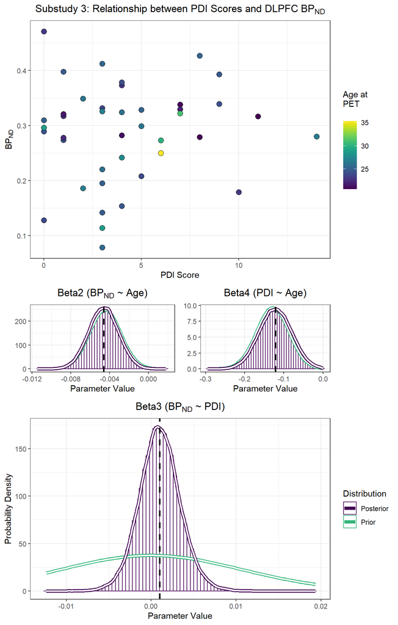

```r
scatter_parest_dlpfc <- pdi_dadb_d1 %>%
  filter(Region=='DLPFC_46') %>%
  mutate(Region = gsub('DLPFC_46', 'DLPFC', Region)) %>%
  ggplot(., aes(x=PDI, y=bp, fill=Age_PET)) +
  #geom_point() +
  geom_point(shape = 21, colour = "black", size = 3) +
  labs(y=expression(BP[ND]), x='PDI Score') +
  viridis::scale_fill_viridis('Age at \nPET\n') +
  theme_bw() + labs(title=bquote('Substudy 3: Relationship between PDI Scores and DLPFC' ~ BP[ND])) +
  theme(plot.title = element_text(hjust = 0.5))

beta2_parest <- distroplot_norm(DLPFC_parest_model, 'beta2', 'beta2_dlpfc_mean', 'beta2_dlpfc_sd') +
  guides(color=F) +
  labs(title=expression(paste('Beta2 (',BP[ND] ,' ~ Age)'))) +
  theme_bw() +
   theme(plot.title = element_text(hjust = 0.5),
         axis.title.y=element_blank()) +
  guides(colour=FALSE)
beta3_parest <- distroplot_norm(DLPFC_parest_model, 'beta3', 0, 'beta3_parest_sd', nbin=80) +
   labs(title=expression(paste('Beta3 (',BP[ND] ,' ~ PDI)'))) +
   theme_bw() +
   theme(plot.title = element_text(hjust = 0.5))
beta4_parest <- distroplot_norm(DLPFC_parest_model, 'beta4', 'beta4_mean', 'beta4_sd') +
  guides(color=F) +
  labs(title=expression(paste('Beta4 (','PDI',' ~ Age)'))) +
   theme_bw() +
  theme(plot.title = element_text(hjust = 0.5),
        axis.title.y=element_blank()) +
  guides(colour=FALSE)
ss3_scatter <- scatter_parest_dlpfc + labs(title="")

ss3_priormean <- mean(bp_dlpfc)/5

ss3_b3_parest <- distroplot_norm_perc(DLPFC_parest_model, 'beta3', 0, 'beta3_parest_sd', meanscale = ss3_priormean, nbin=80) +
   #labs(title=expression(paste('Beta3 (',BP[ND] ,' ~ PDI)'))) +
   labs(title="") +
   theme_bw() +
   theme(plot.title = element_text(hjust = 0.5))
beta4_parest <- distroplot_norm(DLPFC_parest_model, 'beta4', 'beta4_mean', 'beta4_sd') +
  guides(color=F) +
  labs(title=expression(paste('Beta4 (','PDI',' ~ Age)'))) +
   theme_bw() +
  theme(plot.title = element_text(hjust = 0.5),
        axis.title.y=element_blank()) +
  guides(colour=FALSE)
mid_l <- cowplot::align_plots(plotlist = list(scatter_parest_dlpfc, beta2_parest,
                                              beta3_parest), align='v', axis='l')
mid_r <- cowplot::align_plots(plotlist = list(scatter_parest_dlpfc, beta4_parest +
                                                guides(colour=FALSE),
                                              beta3_parest), align='v', axis='r')
midrow <- cowplot::plot_grid(mid_l[[2]], mid_r[[2]], rel_widths = c(0.9,1.1))

plots <- cowplot::align_plots(plotlist = list(scatter_parest_dlpfc, midrow, beta3_parest), align='v', axis='lr')


study5_dlpfc <- cowplot::plot_grid(plots[[1]], midrow, plots[[3]], ncol=1, rel_heights = c(5, 2, 4))

print(study5_dlpfc)
```

```r
ggsave(study5_dlpfc,
  filename = '../Figures/Study5_parest_dlpfc.jpg', width = 7, height=11, dpi=600)

ggsave(scatter_parest_dlpfc,
       filename = '../Figures/Study5_scatter_dlpfc.jpg', width = 7, height=5, dpi=600)
```

```r
mean_dlpfc_beta3_parest <- mean(betas$beta3)
credint_dlpfc_beta3_parest <- coda::HPDinterval(coda::as.mcmc(betas$beta3), prob=0.95)
sd_dlpfc_beta3_parest <- sd(betas$beta3)

mean_beta4_parest <- mean(betas$beta4)
sd_beta4_parest <- sd(betas$beta4)
```

## STR: Decrease Model

For the striatum, we must use different priors both over beta3, but also of beta2: the relationship of BP<sub>ND</sub> with age.

```r
beta2_str_mean <- mean(bp_str)*(str_age_mean)
beta2_str_sd   <- mean(bp_str)*(str_age_sd)

beta3_decreasestr_sd <- (0.192*mean(bp_str))/5

parameters = c('mu', 'sigma', 'beta1', 'beta2', 'beta3', 'beta4')

str_data = list("bp_str", "n", "Age.c", "PDI", "PDIAge.c",
                  "beta2_str_mean", "beta2_str_sd",
                  "beta3_decreasestr_sd",
                  "beta4_mean", "beta4_sd")

myinits <- list(
  list(beta1 = runif(1,-5,5),
       beta2 = rnorm(1,beta2_str_mean,1/beta2_str_sd^2),
       beta3 = -abs(rnorm(1,0,1/beta3_decreasestr_sd^2)),
       beta4 = -abs(rnorm(1,beta4_mean,1/beta4_sd^2)),
       sigma = runif(1,0,100)),
  list(beta1 = runif(1,-5,5),
       beta2 = rnorm(1,beta2_str_mean,1/beta2_str_sd^2),
       beta3 = -abs(rnorm(1,0,1/beta3_decreasestr_sd^2)),
       beta4 = -abs(rnorm(1,beta4_mean,1/beta4_sd^2)),
       sigma = runif(1,0,100)),
  list(beta1 = runif(1,-5,5),
       beta2 = rnorm(1,beta2_str_mean,1/beta2_str_sd^2),
       beta3 = -abs(rnorm(1,0,1/beta3_decreasestr_sd^2)),
       beta4 = -abs(rnorm(1,beta4_mean,1/beta4_sd^2)),
       sigma = runif(1,0,100)))
```

Setting up the model itself:

```r
STR_TCIPDI_modelstring <- "model{

# Data and Likelihood
  for(i in 1:n){
    bp_str[i] ~ dnorm(mu[i], lambda)
    mu[i] <- beta1 + beta2*Age.c[i] + beta3*PDI[i] - beta3*beta4*PDIAge.c[i]*PDI[i]
  }

# Prior for betas
  beta1 ~ dunif( -5 , 5 )
  beta2 ~ dnorm( beta2_str_mean , pow(beta2_str_sd, -2) )
  beta3 ~ dnorm( 0 , pow(beta3_decreasestr_sd, -2))T(,0)
  beta4 ~ dnorm( beta4_mean , pow(beta4_sd, -2) )T(,0)

# Prior for the variance
  lambda <- pow(sigma, -2)
  sigma ~ dunif(0, 100)
}"
```

And now, to run the model:

```r
STR_TCIPDI_model <- jags(str_data, inits = myinits, parameters.to.save = parameters,
                 model.file=textConnection(STR_TCIPDI_modelstring), n.chains=3, n.iter=50000,
         n.burnin=500, DIC=T)
```

[output not shown]

To check that models fitted correctly, we can visualise the traceplots for each of the beta parameters

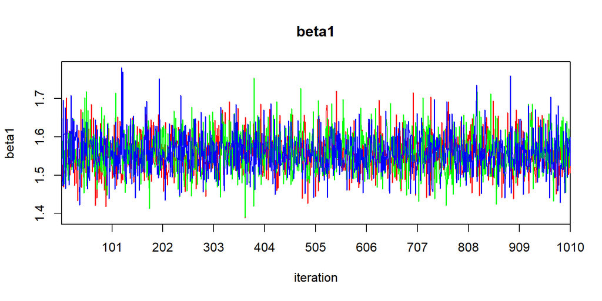

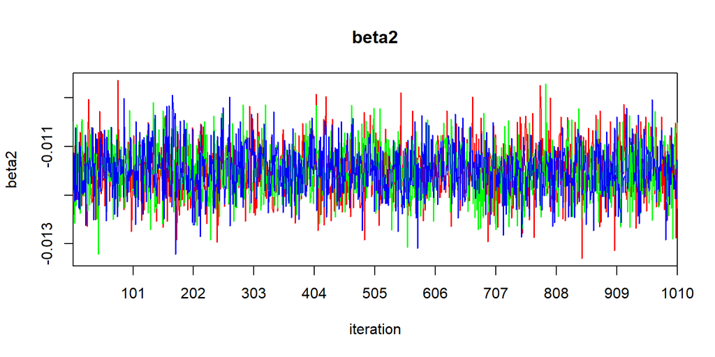

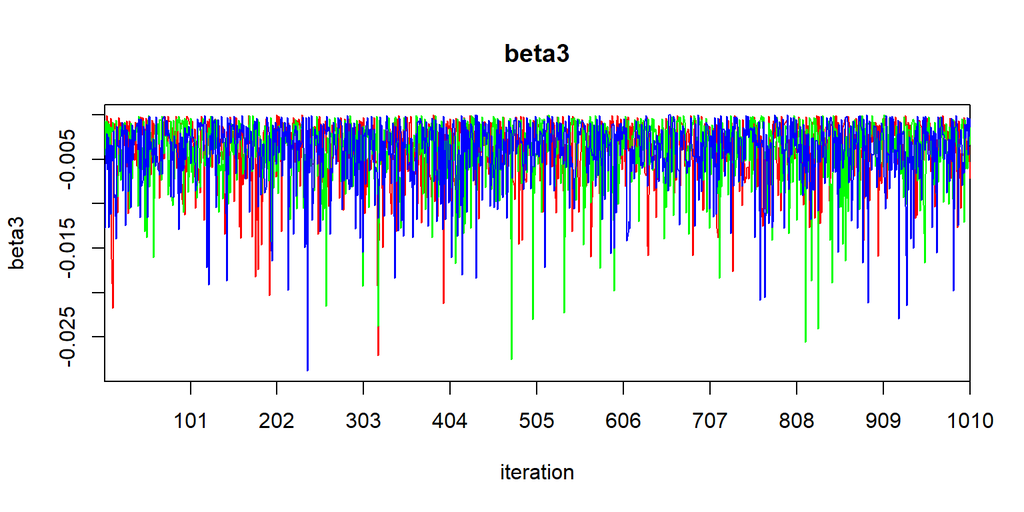

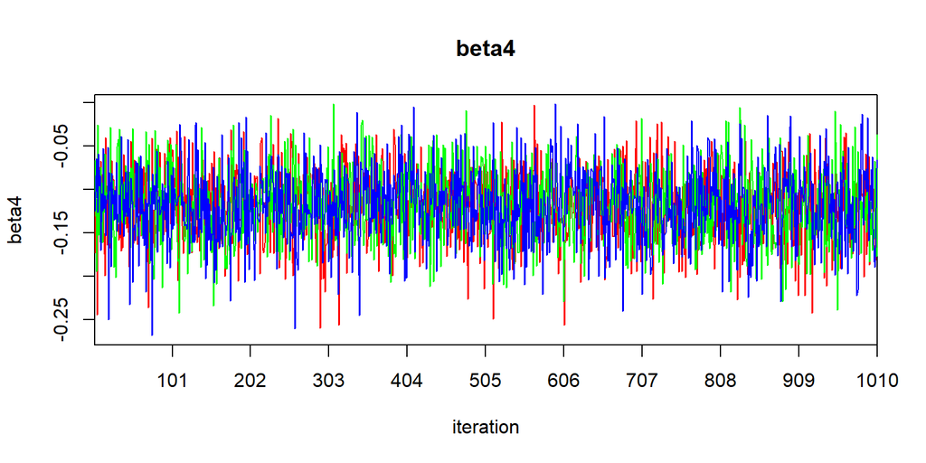

```r
for(i in 1:4) {
  traceplot(STR_TCIPDI_model, varname=paste0('beta',i), ask=F)
}
```

From these, it is concluded that the model performed adequately, as there is no apparent non-stationarity.

Now, we can check the correction parameters, to make sure that posterior estimates seem reasonable

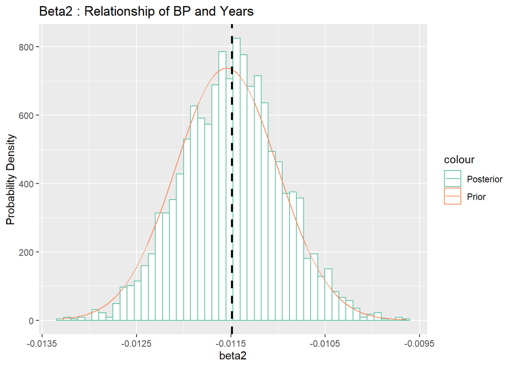

```r
betas <- data.frame(beta1 = STR_TCIPDI_model$BUGSoutput$sims.list$beta1,
                    beta2 = STR_TCIPDI_model$BUGSoutput$sims.list$beta2,
                    beta3 = STR_TCIPDI_model$BUGSoutput$sims.list$beta3,
                    beta4 = STR_TCIPDI_model$BUGSoutput$sims.list$beta4)

ggplot(betas, aes(x=beta2)) +
  #geom_density(aes(colour = "Posterior")) +
  geom_histogram(aes(y = ..density.., colour="Posterior"), bins=50, fill="white") +
  stat_function(fun = dnorm, args = list(mean = beta2_str_mean, sd=beta2_str_sd), aes(colour='Prior')) +
  geom_vline(xintercept=mean(betas$beta2), linetype = "dashed", size=1) +
  scale_colour_brewer(palette = "Set2") +
  labs(title='Beta2 : Relationship of BP and Years',y='Probability Density')
```

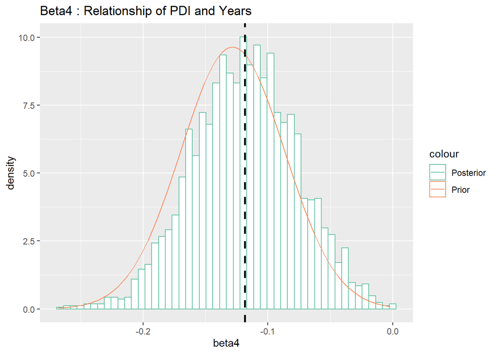

```r
ggplot(betas, aes(x=beta4)) +
  geom_histogram(aes(y = ..density.., colour="Posterior"), bins=50, fill="white") +
  stat_function(fun = dnorm, args = list(mean = beta4_mean, sd=beta4_sd), aes(colour='Prior')) +
  geom_vline(xintercept=mean(betas$beta4), linetype = "dashed", size=1) +
  scale_colour_brewer(palette = "Set2") +
  labs(title='Beta4 : Relationship of PDI and Years')
```

For beta3, the parameter of interest here, we wish to use the Savage Dickey approximation to calculate the Bayes factor.

```r
fit.posterior <- logspline(betas$beta3, ubound=0)

posterior <- dlogspline(0, fit.posterior) # this gives the pdf at point delta = 0
prior     <- 2*dnorm(0,0,beta3_decreasestr_sd)
BF01      <- posterior/prior
BF01
```

```
## [1] 16.13932
```

This means that the null hypothesis is 16.14 times more likely than the alternative hypothesis, that there is an effect of the size specified in the decrease prior, and that the Bayes Factor for the alternative hypothesis is 0.062

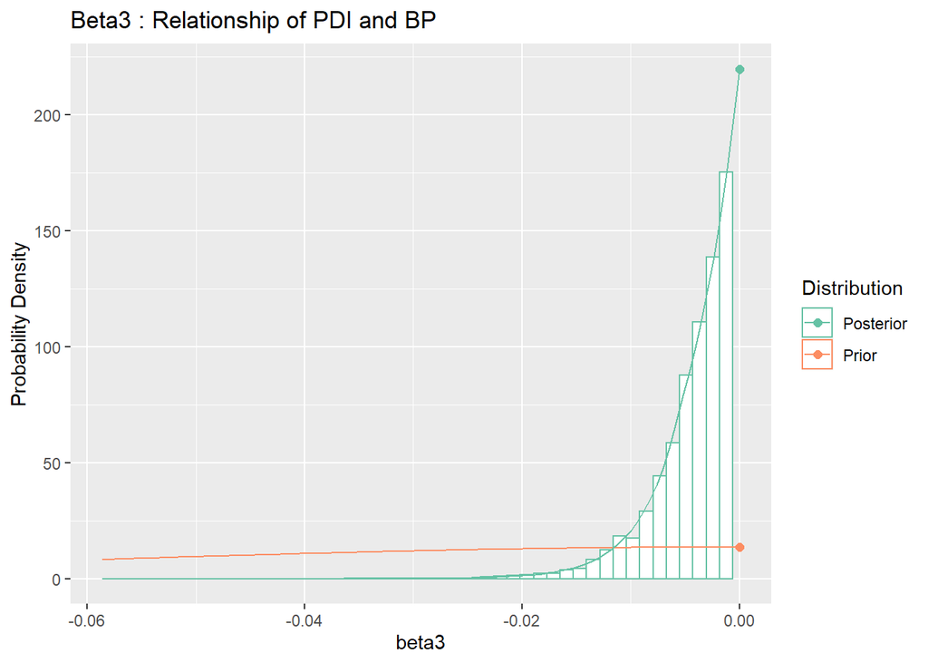

```r
savagedickey_str_decrease <- data.frame(
  Values = c(posterior,prior),
  Distribution = c('Posterior', 'Prior'),
  Model = 'TCIPDI-Striatum'
)

ggplot(betas, aes(x=beta3)) +
  geom_histogram(aes(y = ..density.., colour="Posterior"), bins=49, fill="white") +
  stat_function(fun = dtruncnorm, args = list(mean = 0, sd=beta3_decreasestr_sd,a=-Inf, b=0), aes(colour='Prior')) +
  scale_colour_brewer(palette = "Set2", 'Distribution') +
  xlim(c(-beta3_decreasestr_sd, 0)) +
  stat_function(fun = dlogspline, args=list(fit=fit.posterior), aes(colour='Posterior')) +
  geom_point(data=savagedickey_str_decrease, aes(x=0,y=Values, colour=Distribution), size=2) +
  labs(title='Beta3 : Relationship of PDI and BP',
       y='Probability Density')
```

## STR: Parameter Estimation

This is a similar procedure as for the DLPFC. Here we again use the same prior width as for the decrease comparison

```r
beta3_pareststr_sd <- (0.192*mean(bp_str))/5

str_data = list("bp_str", "n", "Age.c", "PDI", "PDIAge.c",
                  "beta2_str_mean", "beta2_str_sd",
                  "beta3_pareststr_sd",
                  "beta4_mean", "beta4_sd")

myinits <- list(
  list(beta1 = runif(1,-5,5),
       beta2 = rnorm(1,beta2_str_mean,1/beta2_str_sd^2),
       beta3 = rnorm(1,0,1/beta3_decreasestr_sd^2),
       beta4 = -abs(rnorm(1,beta4_mean,1/beta4_sd^2)),
       sigma = runif(1,0,100)),
  list(beta1 = runif(1,-5,5),
       beta2 = rnorm(1,beta2_str_mean,1/beta2_str_sd^2),
       beta3 = rnorm(1,0,1/beta3_decreasestr_sd^2),
       beta4 = -abs(rnorm(1,beta4_mean,1/beta4_sd^2)),
       sigma = runif(1,0,100)),
  list(beta1 = runif(1,-5,5),
       beta2 = rnorm(1,beta2_str_mean,1/beta2_str_sd^2),
       beta3 = rnorm(1,0,1/beta3_decreasestr_sd^2),
       beta4 = -abs(rnorm(1,beta4_mean,1/beta4_sd^2)),
       sigma = runif(1,0,100)))
```

Setting up the model itself:

```r
STR_parest_modelstring <- "model{

# Data and Likelihood
  for(i in 1:n){
    bp_str[i] ~ dnorm(mu[i], lambda)
    mu[i] <- beta1 + beta2*Age.c[i] + beta3*PDI[i] - beta3*beta4*PDIAge.c[i]*PDI[i]
  }

# Prior for betas
  beta1 ~ dunif( -5 , 5 )
  beta2 ~ dnorm( beta2_str_mean , pow(beta2_str_sd, -2) )
  beta3 ~ dnorm( 0 , pow(beta3_pareststr_sd, -2))
  beta4 ~ dnorm( beta4_mean , pow(beta4_sd, -2) )T(,0)

# Prior for the variance
  lambda <- pow(sigma, -2)
  sigma ~ dunif(0, 100)
}"
```

And now, to run the model:

```r
STR_parest_model <- jags(str_data, inits = myinits, parameters.to.save = parameters,
                 model.file=textConnection(STR_parest_modelstring), n.chains=3, n.iter=50000,
         n.burnin=500, n.thin=2)
```

[output not shown]

To check that models fitted correctly, we can visualise the traceplots for each of the beta parameters

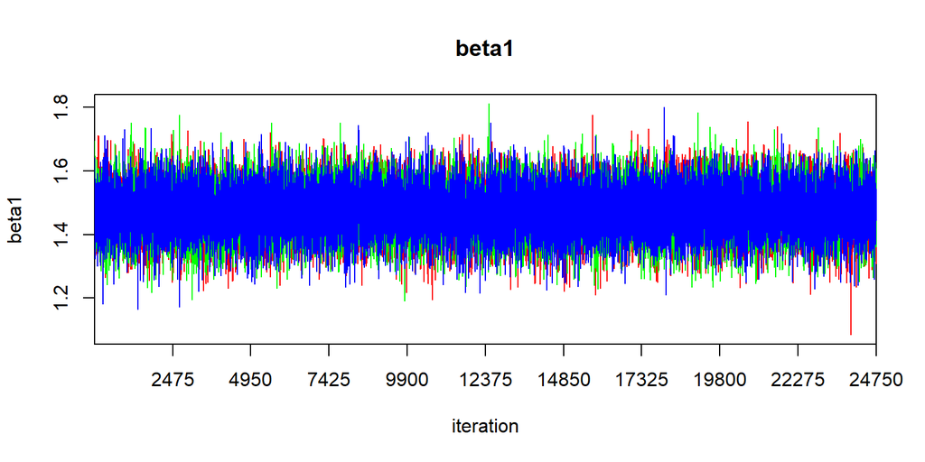

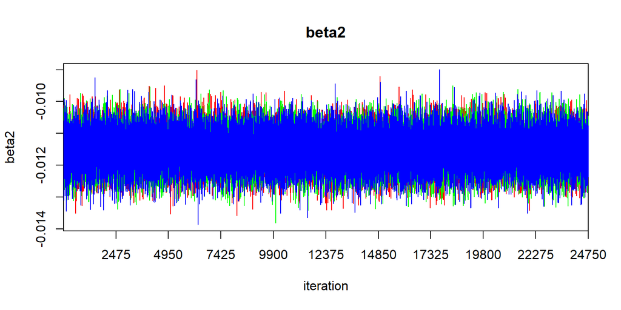

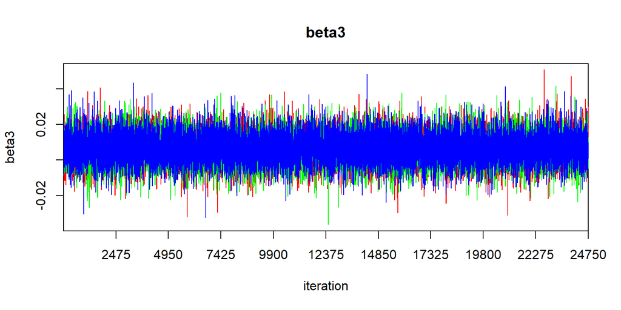

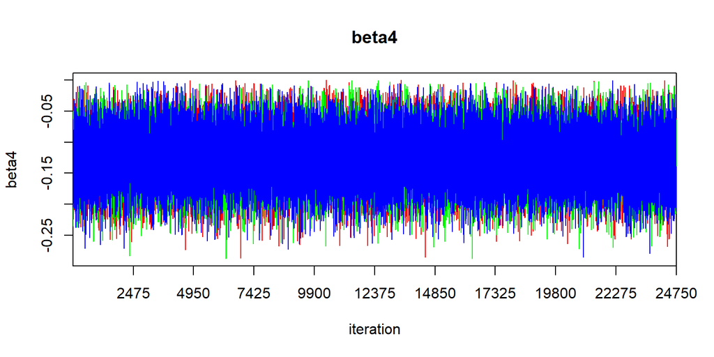

```r
for(i in 1:4) {
  traceplot(STR_parest_model, varname=paste0('beta',i), ask=F)
}
```

From these, it is concluded that the model performed adequately, as there is no apparent non-stationarity.

Now, we can check the correction parameters, to make sure that posterior estimates seem reasonable

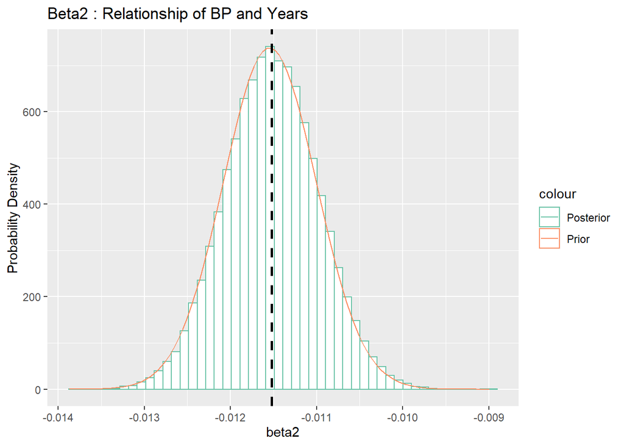

```r
betas <- data.frame(beta1 = STR_parest_model$BUGSoutput$sims.list$beta1,
                    beta2 = STR_parest_model$BUGSoutput$sims.list$beta2,
                    beta3 = STR_parest_model$BUGSoutput$sims.list$beta3,
                    beta4 = STR_parest_model$BUGSoutput$sims.list$beta4)

ggplot(betas, aes(x=beta2)) +
  #geom_density(aes(colour = "Posterior")) +
  geom_histogram(aes(y = ..density.., colour="Posterior"), bins=50, fill="white") +
  stat_function(fun = dnorm, args = list(mean = beta2_str_mean, sd=beta2_str_sd), aes(colour='Prior')) +
  geom_vline(xintercept=mean(betas$beta2), linetype = "dashed", size=1) +
  scale_colour_brewer(palette = "Set2") +
  labs(title='Beta2 : Relationship of BP and Years',y='Probability Density')
```

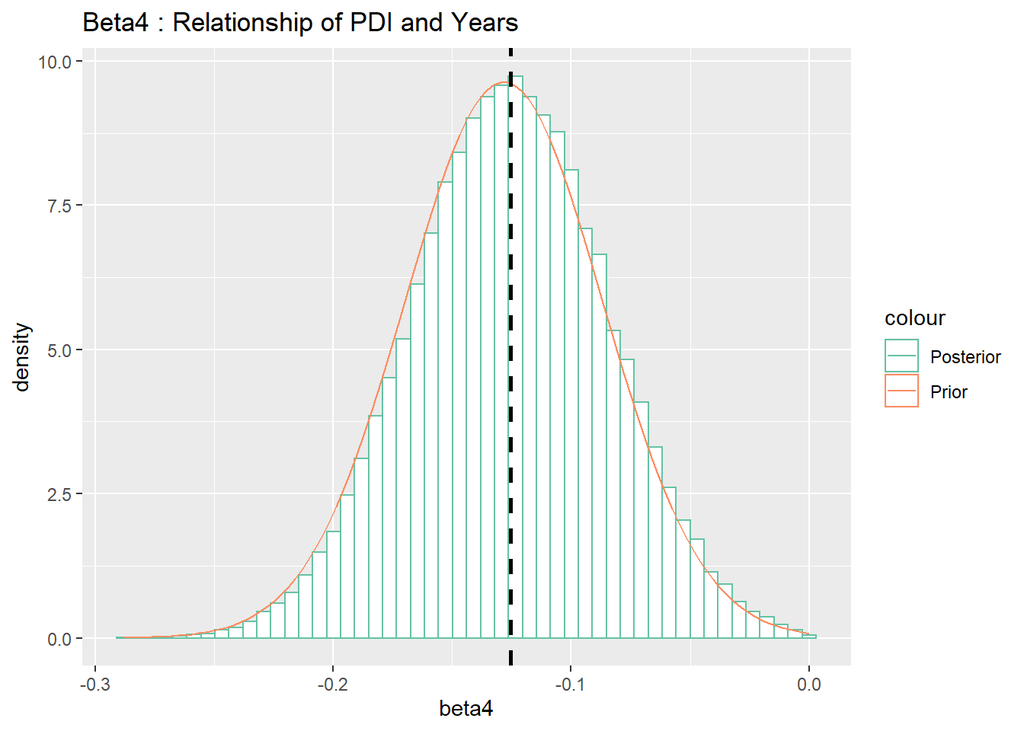

```r
ggplot(betas, aes(x=beta4)) +
  geom_histogram(aes(y = ..density.., colour="Posterior"), bins=50, fill="white") +
  stat_function(fun = dnorm, args = list(mean = beta4_mean, sd=beta4_sd), aes(colour='Prior')) +
  geom_vline(xintercept=mean(betas$beta4), linetype = "dashed", size=1) +
  scale_colour_brewer(palette = "Set2") +
  labs(title='Beta4 : Relationship of PDI and Years')
```

### Publication Figure

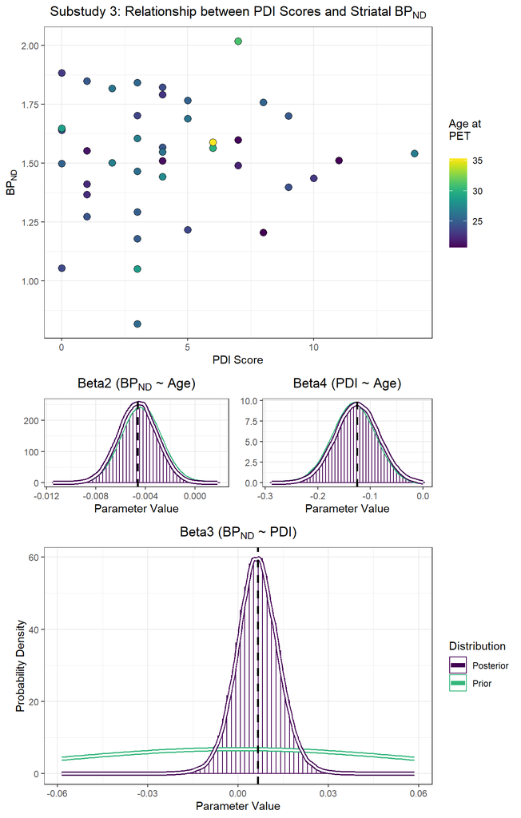

```r
scatter_parest_str <- pdi_dadb_d1 %>%
  filter(Region=='gmfslSTR') %>%
  mutate(Region = gsub('gmfslSTR', 'Striatum', Region)) %>%
  ggplot(., aes(x=PDI, y=bp, fill=Age_PET)) +
  #geom_point() +
  geom_point(shape = 21, colour = "black", size = 3) +
  labs(y=expression(BP[ND]), x='PDI Score') +
  viridis::scale_fill_viridis('Age at \nPET\n') +
  theme_bw() + labs(title=bquote('Substudy 3: Relationship between PDI Scores and Striatal' ~ BP[ND])) +
  theme(plot.title = element_text(hjust = 0.5))

beta2_parest_str <- distroplot_norm(STR_parest_model, 'beta2', 'beta2_str_mean', 'beta2_str_sd') +
  guides(color=F) +
  labs(title=expression(paste('Beta3 (',BP[ND] ,' ~ PDI)'))) +
   theme_bw() +
   theme(plot.title = element_text(hjust = 0.5),
         axis.title.y=element_blank()) +
  guides(colour=FALSE)
beta3_parest <- distroplot_norm(STR_parest_model, 'beta3', 0, 'beta3_pareststr_sd', nbin=80) +
  labs(title=expression(paste('Beta3 (',BP[ND] ,' ~ PDI)'))) +
   theme_bw() +
   theme(plot.title = element_text(hjust = 0.5))
beta4_parest <- distroplot_norm(STR_parest_model, 'beta4', 'beta4_mean', 'beta4_sd') +
  guides(color=F) +
  labs(title=expression(paste('Beta4 (','PDI',' ~ Age)'))) +
   theme_bw() +
  theme(plot.title = element_text(hjust = 0.5),
        axis.title.y=element_blank()) +
  guides(colour=FALSE)
# grid.arrange(scatter_parest_str,
#              beta2_parest,
#              beta4_parest,
#              beta3_parest,
#              layout_matrix = rbind(c(1,1), c(2,3), c(4,4)),
#              widths=c(1,1), heights=c(2,1,2))
#
# ggsave(
#   grid.arrange(scatter_parest_str,
#              beta2_parest,
#              beta4_parest,
#              beta3_parest,
#              layout_matrix = rbind(c(1,1), c(2,3), c(4,4)),
#              widths=c(1,1), heights=c(2,1,2)),
#   filename = '../Figures/Study5_parest_str.jpg', width = 7, height=11, dpi=600)

mid_l <- cowplot::align_plots(plotlist = list(scatter_parest_str, beta2_parest,
                                              beta3_parest), align='v', axis='l')
mid_r <- cowplot::align_plots(plotlist = list(scatter_parest_str, beta4_parest +
                                                guides(colour=FALSE),
                                              beta3_parest), align='v', axis='r')
midrow <- cowplot::plot_grid(mid_l[[2]], mid_r[[2]], rel_widths = c(0.9,1.1))

plots <- cowplot::align_plots(plotlist = list(scatter_parest_str, midrow, beta3_parest), align='v', axis='lr')


study5_str <- cowplot::plot_grid(plots[[1]], midrow, plots[[3]], ncol=1, rel_heights = c(5, 2, 4))

print(study5_str)
```

```r
ggsave(study5_str,
  filename = '../Figures/Study5_parest_str.jpg', width = 7, height=11, dpi=600)
```

For beta3, the parameter of interest here, our estimate is as follows:

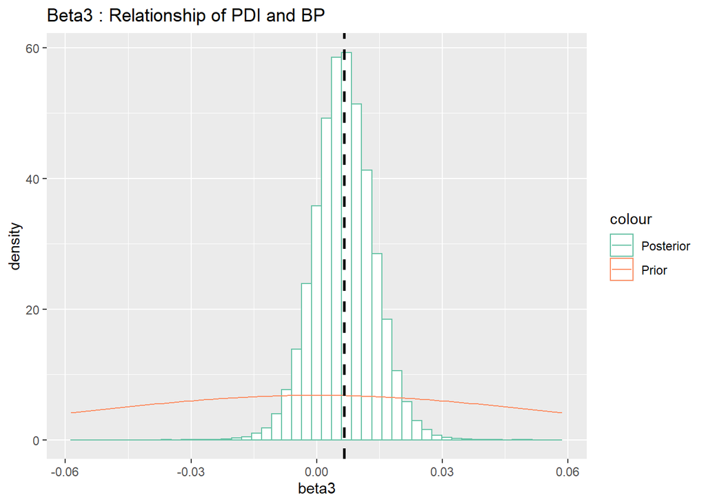

```r
ggplot(betas, aes(x=beta3)) +
  geom_histogram(aes(y = ..density.., colour="Posterior"), bins=50, fill="white") +
  stat_function(fun = dnorm, args = list(mean = 0, sd=beta3_pareststr_sd), aes(colour='Prior')) +
  geom_vline(xintercept=mean(betas$beta3), linetype = "dashed", size=1) +
  scale_colour_brewer(palette = "Set2") +
  lims(x=c(-beta3_pareststr_sd, beta3_pareststr_sd)) +
  labs(title='Beta3 : Relationship of PDI and BP')
```

```r
mean_str_beta3_parest <- mean(betas$beta3)
credint_str_beta3_parest <- coda::HPDinterval(coda::as.mcmc(betas$beta3), prob=0.95)
sd_str_beta3_parest <- sd(betas$beta3)
```

```r
str_parest_summary <- as.data.frame(MCMCvis::MCMCsummary(STR_parest_model, params = c('beta1', 'beta2', 'beta3', 'beta4'), digits=3))
```

## Publication Parameter Estimation Summary

```r
parest_summary <- bind_rows(rownames_to_column(dlpfc_parest_summary), rownames_to_column(str_parest_summary)) %>%
  select(Parameter=rowname, Mean=mean, SD=sd, everything(), -`50%`) %>%
  mutate(Parameter = stringr::str_to_title(Parameter))

kable(parest_summary)
```

| Parameter | Mean | SD | 2.5% | 97.5% | Rhat | n.eff |
| --- | --- | --- | --- | --- | --- | --- |
| Beta1 | 0.27900 | 0.023600 | 0.23300 | 0.32600 | 1 | 23905 |
| Beta2 | -0.00463 | 0.001550 | -0.00766 | -0.00160 | 1 | 74250 |
| Beta3 | 0.00101 | 0.002430 | -0.00376 | 0.00595 | 1 | 26245 |
| Beta4 | -0.12200 | 0.041600 | -0.20300 | -0.03990 | 1 | 72227 |
| Beta1 | 1.47000 | 0.069500 | 1.34000 | 1.61000 | 1 | 25864 |
| Beta2 | -0.01150 | 0.000542 | -0.01260 | -0.01050 | 1 | 74250 |
| Beta3 | 0.00655 | 0.007090 | -0.00737 | 0.02080 | 1 | 28037 |
| Beta4 | -0.12500 | 0.041000 | -0.20600 | -0.04530 | 1 | 72813 |

```r
parest_summarytable <- kable(parest_summary, format='latex', caption='Posterior summaries of unstandardised coefficients from parameter estimation regression models', booktab=T, digits=3) %>%
  group_rows('DLPFC', 1,4) %>%
  group_rows('Striatum', 5,8)
```

### DLPFC

```r
dlpfc_parest_accsummary <- as.data.frame(MCMCvis::MCMCsummary(DLPFC_parest_model, params = c('beta1', 'beta2', 'beta3', 'beta4'), digits=10))
str_parest_accsummary <- as.data.frame(MCMCvis::MCMCsummary(STR_parest_model, params = c('beta1', 'beta2', 'beta3', 'beta4')), digits=10)
```

Correspondingly, a change of five points on the PDI is associated with a change of 1.8% (-6.6 - 10.4% 95% Credible Interval), and the change across the entire scale of 21 items corresponds with a change of 7.4% (-27.5 - 43.6% Credible Interval)

### STR

Correspondingly, a change of five points on the PDI is associated with a change of 2.1% (-2.4 - 6.8% 95% Credible Interval), and the change across the entire scale of 21 items corresponds with a change of 9% (-10.1 - 28.6% Credible Interval)

# Substudy 4: Bayesian estimation of the relationship between D1 Receptor BP<sub>ND</sub> and PDI scores

The findings in the previous study of the relationship between PDI scores and D1 receptor BP<sub>ND</sub> supported the null hypothesis when using priors to represent the effects which we might have expected from previous studies. This suggests that these hypotheses are unlikely given our data. Use of Bayes Factors comprises a model selection procedure, which, in this case supported a point null hypothesis of their being absolutely no effect in comparison to the other hypotheses.

Using a parameter estimation procedure, we can use the final dataset to obtain a posterior distribution reflecting the probability of parameter values given the data reflecting the strength of relationship between PDI scores and D1 receptor binding. Future studies of this phenomenon can then use this posterior as the prior for their investigations.

We can build on the parameter estimation performed in study 5, and use that posterior as the prior for this study.

```r
(d1spdi_priormean <- mean_dlpfc_beta3_parest )
```

```
## [1] 0.001005913
```

```r
(d1spdi_priorwidth <- sd_dlpfc_beta3_parest )
```

```
## [1] 0.002434331
```

```r
(beta4_mean <- mean_beta4_parest )
```

```
## [1] -0.1215805
```

```r
(beta4_width <- sd_beta4_parest )
```

```
## [1] 0.04164544
```

We cannot simply use this value without knowing whether the mean BP<sub>ND</sub> differs between the two samples

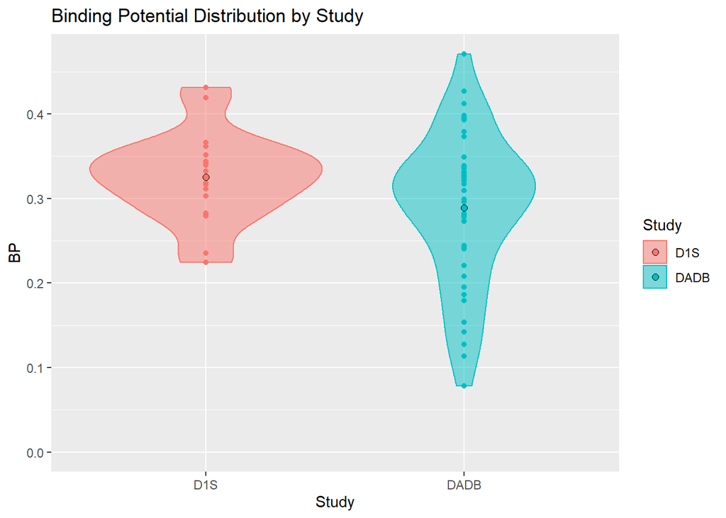

```r
compareStudies <- alldata %>%
  filter(!is.na(bp), PETNo==1, Region=='DLPFC_46') %>%
  filter(Age >= 20 & Age <=35) %>%
  filter(Sex=='male')


ggplot(compareStudies, aes(y=bp, x=Study, colour=Study, fill=Study)) +
    geom_violin(alpha=0.5) +
    geom_point() +
    labs(y='BP',
         title='Binding Potential Distribution by Study') +
    expand_limits(y=0) +
    stat_summary(fun.y = "mean", colour = "black", size = 2, geom = "point", shape=21)
```

There appears to be a difference between the binding potential of the two studies. I therefore scale this prior width to the new mean.

```r
t.test(formula=bp~Study, data=compareStudies)
```

```
##
##  Welch Two Sample t-test
##
## data:  bp by Study
## t = 2.0782, df = 57.787, p-value = 0.04214
## alternative hypothesis: true difference in means is not equal to 0
## 95 percent confidence interval:
##  0.001337395 0.071499248
## sample estimates:
##  mean in group D1S mean in group DADB
##          0.3254798          0.2890614
```

```r
studymeans <- compareStudies %>%
  group_by(Study) %>%
  summarise(bp=mean(bp))

meanratio <- studymeans$bp[studymeans$Study=='D1S'] /
                studymeans$bp[studymeans$Study=='DADB']

priormean_d1spdi <- d1spdi_priormean * meanratio
priorwidth_d1spdi <- d1spdi_priorwidth * meanratio
```

First, I will check that the PDI is sufficiently reliable within this sample

```r
pdi_d1s <- alldata %>%
  filter(!is.na(bp), PETNo==1, Region=='DLPFC_46') %>%
  filter(Study=='D1S', !is.na(PDI)) %>%
  filter(SubjName != 'ivhe')    # missing second page of answers

pdi_d1s_answers <- pdi_d1s %>%
  select(starts_with('PDI_Q'))

(pdi_d1s_reliability <- alpha(pdi_d1s_answers))
```

```
## Some items ( PDI_Q4 PDI_Q11 PDI_Q15 PDI_Q16 PDI_Q17 PDI_Q18 ) were negatively correlated with the total scale and
## probably should be reversed.
## To do this, run the function again with the 'check.keys=TRUE' option
```

[output not shown]

[output not shown]

[output not shown]

[output not shown]

[output not shown]

[output not shown]

[output not shown]

[output not shown]

[output not shown]

[output not shown]

[output not shown]

[output not shown]

[output not shown]

[output not shown]

[output not shown]

[output not shown]

[output not shown]

[output not shown]

[output not shown]

```
##
## Reliability analysis
## Call: alpha(x = pdi_d1s_answers)
##
##   raw_alpha std.alpha G6(smc) average_r S/N ase mean   sd median_r
##       0.68      0.64    0.83      0.09 1.8 0.1 0.18 0.14   -0.053
##
##  lower alpha upper     95% confidence boundaries
## 0.48 0.68 0.87
##
##  Reliability if an item is dropped:
##         raw_alpha std.alpha G6(smc) average_r S/N alpha se var.r   med.r
## PDI_Q1       0.63      0.60    0.80     0.081 1.5    0.118 0.067 -0.0526
## PDI_Q3       0.65      0.61    0.80     0.085 1.6    0.111 0.067 -0.0526
## PDI_Q4       0.69      0.65    0.82     0.099 1.9    0.097 0.066 -0.0231
## PDI_Q5       0.68      0.65    0.87     0.100 1.9    0.100 0.068 -0.0231
## PDI_Q6       0.67      0.64    0.80     0.094 1.8    0.102 0.069 -0.0526
## PDI_Q7       0.63      0.60    0.78     0.080 1.5    0.117 0.068 -0.0526
## PDI_Q8       0.67      0.62    0.84     0.087 1.6    0.103 0.064 -0.0526
## PDI_Q9       0.66      0.61    0.76     0.085 1.6    0.106 0.066 -0.0526
## PDI_Q10      0.66      0.62    0.79     0.089 1.7    0.106 0.066 -0.0431
## PDI_Q11      0.69      0.67    0.87     0.106 2.0    0.096 0.066  0.0101
## PDI_Q13      0.66      0.62    0.85     0.086 1.6    0.107 0.060 -0.0431
## PDI_Q14      0.66      0.62    0.85     0.088 1.6    0.106 0.061 -0.0335
## PDI_Q15      0.66      0.61    0.80     0.085 1.6    0.105 0.066 -0.0526
## PDI_Q16      0.70      0.65    0.82     0.098 1.8    0.090 0.066 -0.0526
## PDI_Q17      0.69      0.66    0.80     0.104 2.0    0.098 0.068 -0.0023
## PDI_Q18      0.69      0.66    0.82     0.102 1.9    0.097 0.065 -0.0023
## PDI_Q20      0.62      0.58    0.82     0.075 1.4    0.117 0.062 -0.0526
## PDI_Q21      0.65      0.60    0.88     0.082 1.5    0.108 0.064 -0.0431
##
##  Item statistics
##          n  raw.r std.r  r.cor r.drop mean   sd
## PDI_Q1  20  0.638 0.569  0.567  0.494 0.55 0.51
## PDI_Q3  20  0.547 0.489  0.493  0.390 0.35 0.49
## PDI_Q4  20  0.162 0.198  0.182  0.041 0.10 0.31
## PDI_Q5  20  0.158 0.172  0.068  0.070 0.05 0.22
## PDI_Q6  20  0.346 0.308  0.302  0.210 0.15 0.37
## PDI_Q7  20  0.638 0.588  0.605  0.494 0.55 0.51
## PDI_Q8  20  0.364 0.432  0.312  0.252 0.10 0.31
```

[output cut: 17 more lines]

```
## PDI_Q5  0.95 0.05    0
## PDI_Q6  0.85 0.15    0
## PDI_Q7  0.45 0.55    0
## PDI_Q8  0.90 0.10    0
## PDI_Q9  0.85 0.15    0
## PDI_Q10 0.90 0.10    0
## PDI_Q11 0.95 0.05    0
## PDI_Q13 0.85 0.15    0
## PDI_Q14 0.90 0.10    0
## PDI_Q15 0.85 0.15    0
## PDI_Q16 0.55 0.45    0
## PDI_Q17 0.95 0.05    0
## PDI_Q18 0.95 0.05    0
## PDI_Q20 0.85 0.15    0
## PDI_Q21 0.95 0.05    0
```

We observe a Cronbach’s $\alpha$ of 0.68. This is not particularly good, but useable. This means that we can proceed with this study.

First, some summary statistics

```r
kable(psych::describe(pdi_d1s$PDI), digits = 2)
```

|  | vars | n | mean | sd | median | trimmed | mad | min | max | range | skew | kurtosis | se |
| --- | --- | --- | --- | --- | --- | --- | --- | --- | --- | --- | --- | --- | --- |
| X1 | 1 | 20 | 3.3 | 2.54 | 3 | 3.06 | 2.97 | 0 | 9 | 9 | 0.49 | -0.49 | 0.57 |

```r
kable(psych::describe(pdi_d1s$bp), digits = 2)
```

|  | vars | n | mean | sd | median | trimmed | mad | min | max | range | skew | kurtosis | se |
| --- | --- | --- | --- | --- | --- | --- | --- | --- | --- | --- | --- | --- | --- |
| X1 | 1 | 20 | 0.33 | 0.05 | 0.33 | 0.32 | 0.04 | 0.22 | 0.43 | 0.21 | 0.05 | -0.22 | 0.01 |

And now to define everything for the model. Note that since everyone completed their PDI questionnaires within two weeks of their PET measurement, PDIAge.c is considered to be equal to PETAge.c. The model definition is thus as follows:

$$BP_{ND} = \beta_{1} + \beta_{2}PETAge.c + \beta_{3}PDI - \beta_{3}\beta_{4}PETAge.c \times PDI$$

```r
bp_dlpfc <- pdi_d1s$bp
n = nrow(pdi_d1s)
Age.c = pdi_d1s$Age - mean(pdi_d1s$Age)
PDI = pdi_d1s$PDI

beta2_dlpfc_mean <- mean(bp_dlpfc)*(beta2_dlpfc_mean_update)
beta2_dlpfc_sd   <- mean(bp_dlpfc)*(beta2_dlpfc_sd_update)

beta3_pdi_mean <- priormean_d1spdi
beta3_pdi_sd <- abs(priorwidth_d1spdi)

beta3_pdi_mean <- priormean_d1spdi
beta3_pdi_sd <- abs(priorwidth_d1spdi)

beta4_mean <- beta4_mean
beta4_sd   <- beta4_sd

parameters = c('mu', 'sigma', 'beta1', 'beta2', 'beta3', 'beta4')

dlpfc_data = list("bp_dlpfc", "n", "Age.c", "PDI",
                  "beta2_dlpfc_mean", "beta2_dlpfc_sd",
                  "beta3_pdi_mean", "beta3_pdi_sd",
                  "beta4_mean", "beta4_sd")

myinits <- list(
  list(beta1 = runif(1,-5,5),
       beta2 = rnorm(1,beta2_dlpfc_mean,1/beta2_dlpfc_sd^2),
       beta3 = rnorm(1,beta3_pdi_mean,1/beta3_pdi_sd^2),
       beta4 = rnorm(1,beta4_mean,1/beta4_sd^2),
       sigma = runif(1,0,100)),
  list(beta1 = runif(1,-5,5),
       beta2 = rnorm(1,beta2_dlpfc_mean,1/beta2_dlpfc_sd^2),
       beta3 = rnorm(1,beta3_pdi_mean,1/beta3_pdi_sd^2),
       beta4 = rnorm(1,beta4_mean,1/beta4_sd^2),
       sigma = runif(1,0,100)),
  list(beta1 = runif(1,-5,5),
       beta2 = rnorm(1,beta2_dlpfc_mean,1/beta2_dlpfc_sd^2),
       beta3 = rnorm(1,beta3_pdi_mean,1/beta3_pdi_sd^2),
       beta4 = rnorm(1,beta4_mean,1/beta4_sd^2),
       sigma = runif(1,0,100)))
```

Setting up the model itself:

```r
DLPFC_D1SPDI_modelstring <- "model{

# Data and Likelihood
  for(i in 1:n){
    bp_dlpfc[i] ~ dnorm(mu[i], lambda)
    mu[i] <- beta1 + beta2*Age.c[i] + beta3*PDI[i] - beta3*beta4*Age.c[i]*PDI[i]
  }

# Prior for betas
  beta1 ~ dunif( -5 , 5 )
  beta2 ~ dnorm( beta2_dlpfc_mean , pow(beta2_dlpfc_sd, -2) )
  beta3 ~ dnorm( beta3_pdi_mean , pow(beta3_pdi_sd, -2))
  beta4 ~ dnorm( beta4_mean , pow(beta4_sd, -2) )T(,0)

# Prior for the variance
  lambda <- pow(sigma, -2)
  sigma ~ dunif(0, 100)
}"
```

And now, to run the model:

```r
DLPFC_D1SPDI_model <- jags(dlpfc_data, inits = myinits, parameters.to.save = parameters,
                 model.file=textConnection(DLPFC_D1SPDI_modelstring), n.chains=3, n.iter=50000,
         n.burnin=500, DIC=T, n.thin = 2)
```

[output not shown]

To check that models fitted correctly, we can visualise the traceplots for each of the beta parameters

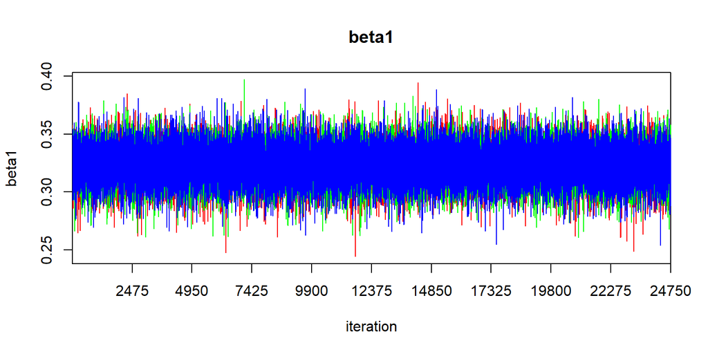

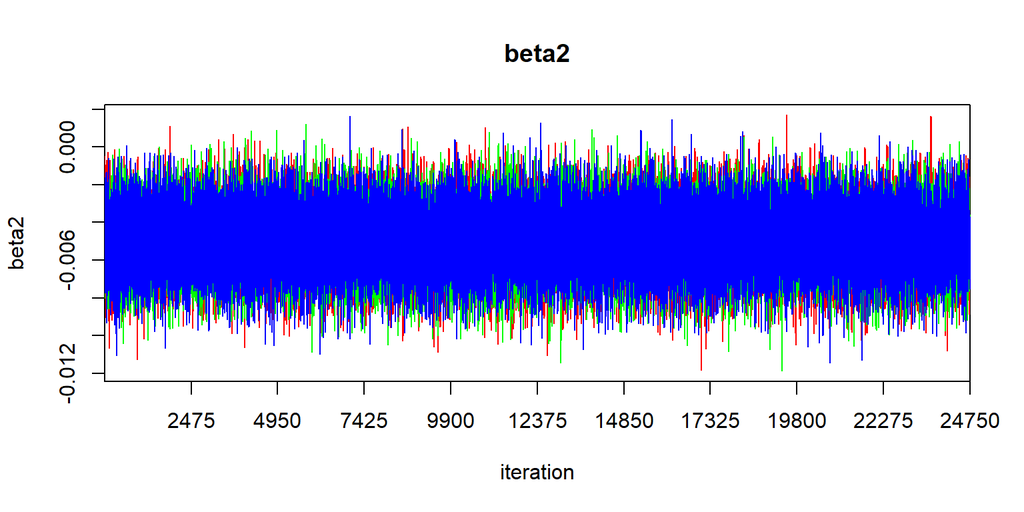

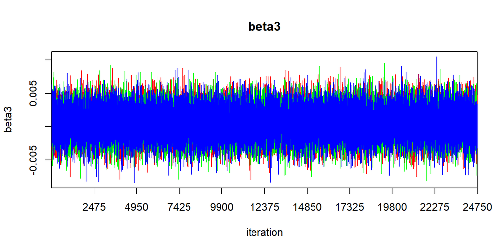

```r
for(i in 1:3) {
  traceplot(DLPFC_D1SPDI_model, varname=paste0('beta',i), ask=F)
}
```

From these, it is concluded that the model performed adequately, as there is no apparent non-stationarity.

Now, we can check the correction for age, to make sure that posterior estimates seem reasonable

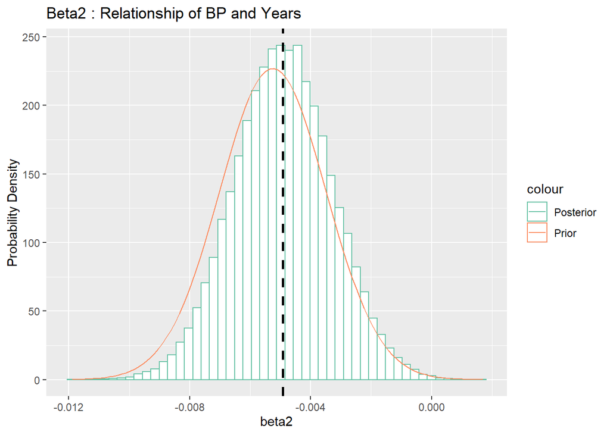

```r
betas <- data.frame(beta1 = DLPFC_D1SPDI_model$BUGSoutput$sims.list$beta1,
                    beta2 = DLPFC_D1SPDI_model$BUGSoutput$sims.list$beta2,
                    beta3 = DLPFC_D1SPDI_model$BUGSoutput$sims.list$beta3,
                    beta4 = DLPFC_D1SPDI_model$BUGSoutput$sims.list$beta4)

ggplot(betas, aes(x=beta2)) +
  #geom_density(aes(colour = "Posterior")) +
  geom_histogram(aes(y = ..density.., colour="Posterior"), bins=50, fill="white") +
  stat_function(fun = dnorm, args = list(mean = beta2_dlpfc_mean, sd=beta2_dlpfc_sd), aes(colour='Prior')) +
  geom_vline(xintercept=mean(betas$beta2), linetype = "dashed", size=1) +
  scale_colour_brewer(palette = "Set2") +
  labs(title='Beta2 : Relationship of BP and Years',y='Probability Density')
```

Next, we can check the posterior predictive distribution to visualise the estimated coefficient for beta4: the relationship of PDI scores and age in this group of individuals.

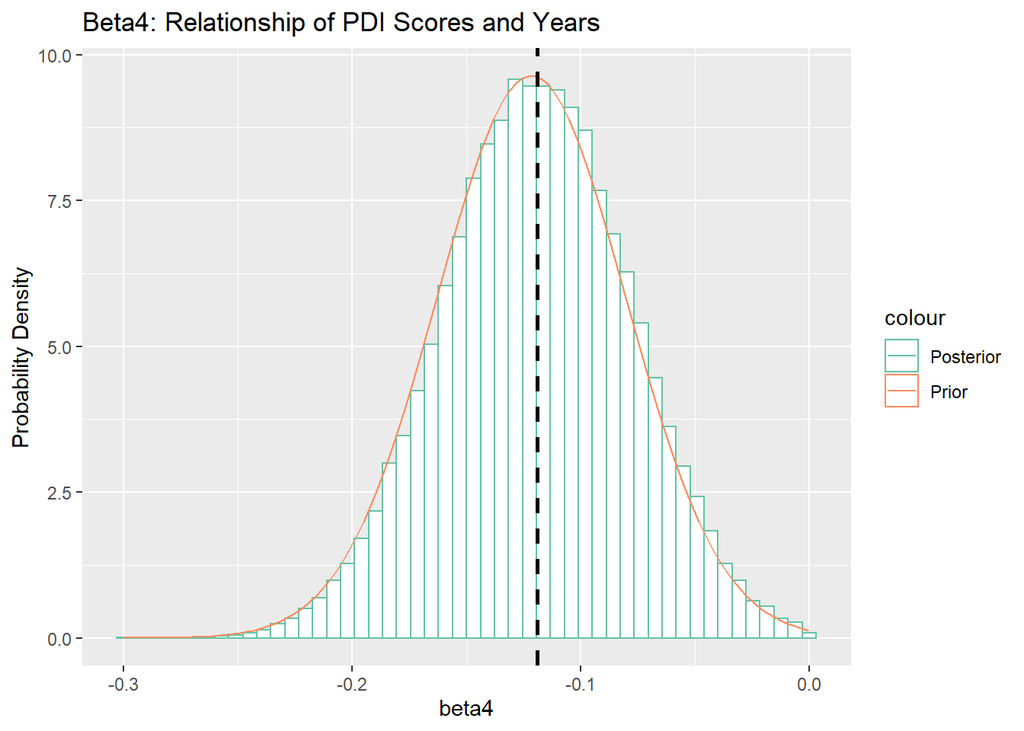

```r
ggplot(betas, aes(x=beta4)) +
  #geom_density(aes(colour = "Posterior")) +
  geom_histogram(aes(y = ..density.., colour="Posterior"), bins=50, fill="white") +
  stat_function(fun = dnorm, args = list(mean = beta4_mean, sd=beta4_sd), aes(colour='Prior')) +
  geom_vline(xintercept=mean(betas$beta4), linetype = "dashed", size=1) +
  scale_colour_brewer(palette = "Set2") +
  labs(title='Beta4: Relationship of PDI Scores and Years',y='Probability Density')
```

Finally, we can check the posterior predictive distribution to visualise the estimated coefficient for beta3: the relationship of BP<sub>ND</sub> and PDI scores in this group of individuals.

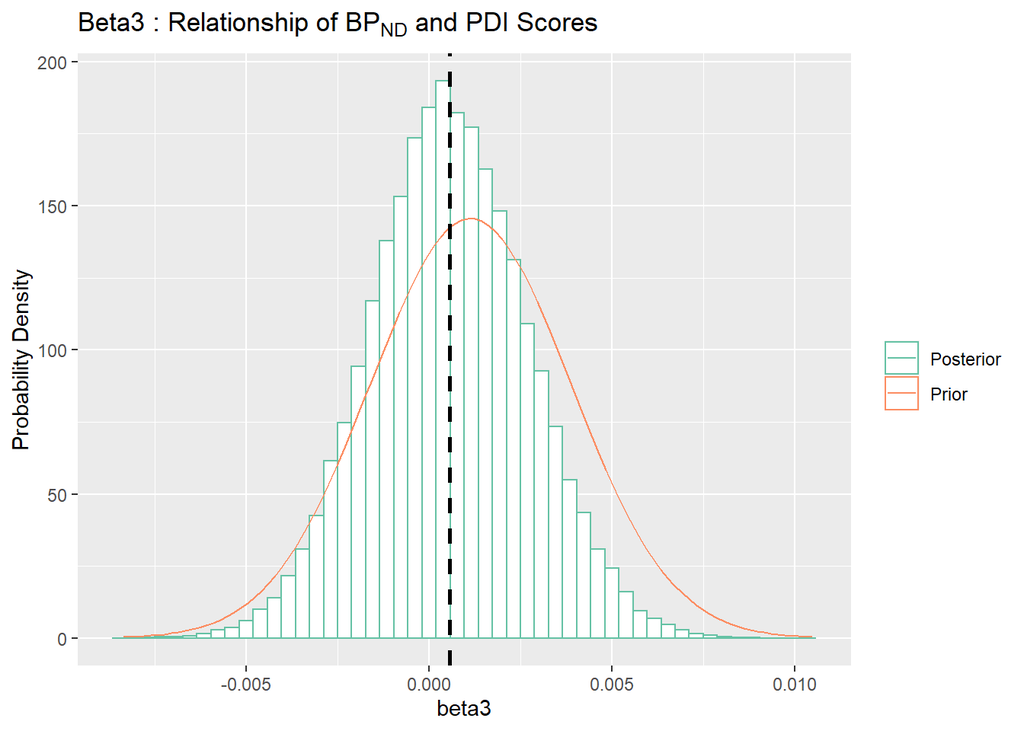

```r
ggplot(betas, aes(x=beta3)) +
  #geom_density(aes(colour = "Posterior")) +
  geom_histogram(aes(y = ..density.., colour="Posterior"), bins=50, fill="white") +
  stat_function(fun = dnorm, args = list(mean = beta3_pdi_mean, sd=beta3_pdi_sd), aes(colour='Prior')) +
  geom_vline(xintercept=mean(betas$beta3), linetype = "dashed", size=1) +
  scale_colour_brewer(palette = "Set2", ' ') +
  expand_limits(x=c(-beta3_pdi_sd, beta3_pdi_sd)) +
  labs(title=expression(paste("Beta3 : Relationship of ", BP[ND]," and PDI Scores",sep="")),
       y = 'Probability Density')
```

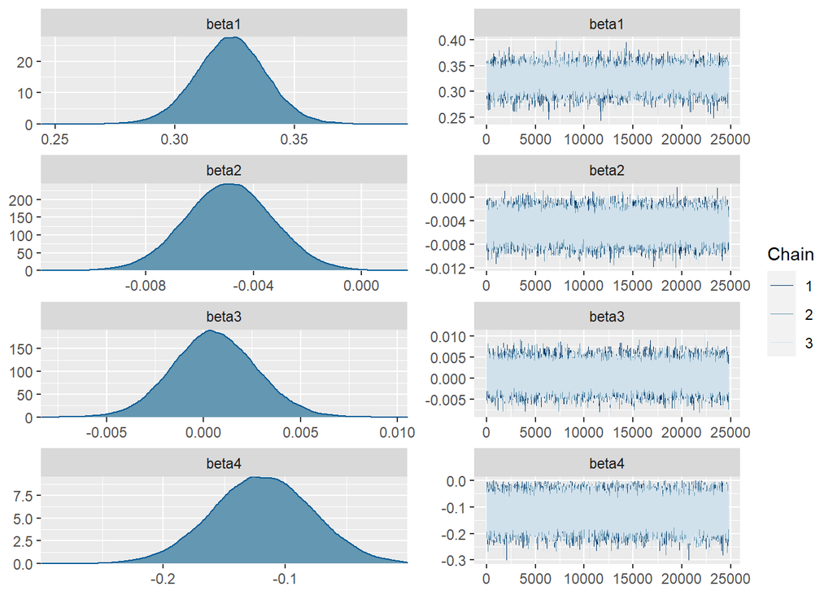

```r
bayesplot::mcmc_combo(as.mcmc(DLPFC_D1SPDI_model, ), regex_pars='beta')
```

```r
(mean_dlpfc_beta3_parest <- mean(betas$beta3))
```

```
## [1] 0.0005594762
```

```r
(credint_dlpfc_beta3_parest <- coda::HPDinterval(coda::as.mcmc(betas$beta3), prob=0.89))
```

```
##             lower       upper
## var1 -0.002932273 0.003925677
## attr(,"Probability")
## [1] 0.8899933
```

```r
(sd_dlpfc_beta3_parest <- sd(betas$beta3))
```

```
## [1] 0.002149555
```

From this, we can see that the new data has shifted the near-zero association from the previous study even closer towards zero. According to our data, there is a 60% chance that the relationship of DLPFC BP<sub>ND</sub> is positive, and a 40% chance that it is negative.

We can also visualise the relationship between these BP<sub>ND</sub>, age and PDI scores.

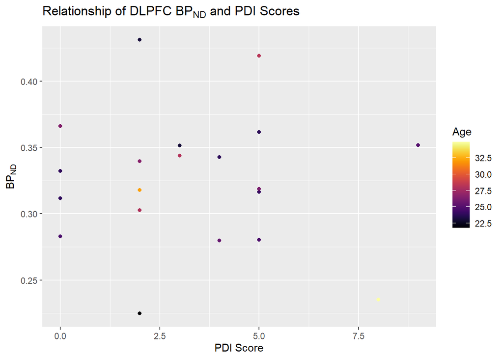

```r
ggplot(pdi_d1s, aes(x=PDI, y=bp, colour=Age)) +
  geom_point() +
  viridis::scale_color_viridis(begin=0, option = 'B') +
  labs(title=expression(paste("Relationship of DLPFC ", BP[ND]," and PDI Scores",sep="")),
       y=expression(BP[ND]),
       x='PDI Score')
```

### Publication Figure

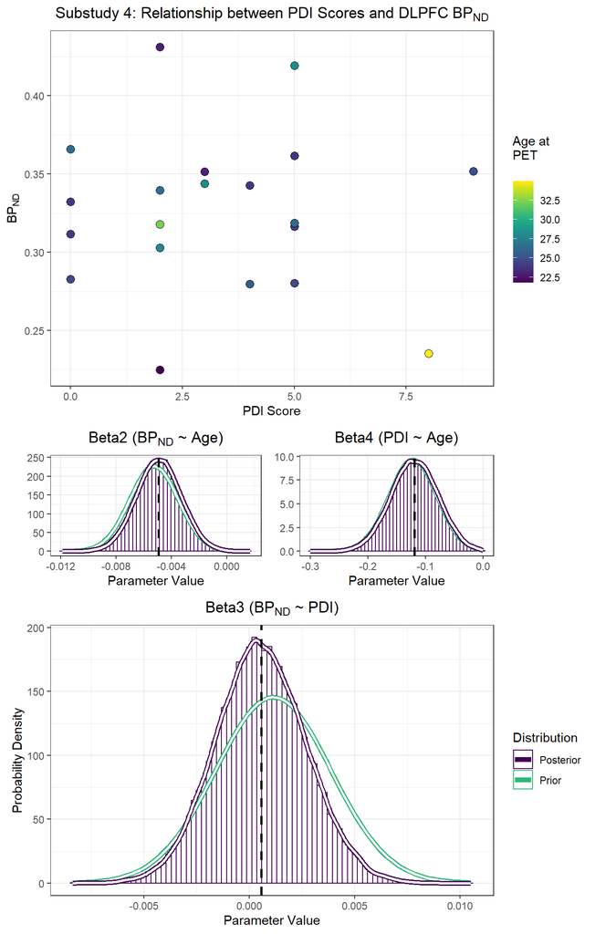

```r
scatter_parest_dlpfc_s6 <- pdi_d1s %>%
  filter(Region=='DLPFC_46') %>%
  mutate(Region = gsub('DLPFC_46', 'DLPFC', Region)) %>%
  ggplot(., aes(x=PDI, y=bp, fill=Age)) +
  #geom_point() +
  geom_point(shape = 21, colour = "black", size = 3) +
  labs(y=expression(BP[ND]), x='PDI Score') +
  viridis::scale_fill_viridis('Age at \nPET\n') +
  theme_bw() + labs(title=bquote('Substudy 4: Relationship between PDI Scores and DLPFC' ~ BP[ND])) +
  theme(plot.title = element_text(hjust = 0.5))

beta2_parest <- distroplot_norm(DLPFC_D1SPDI_model, 'beta2', 'beta2_dlpfc_mean', 'beta2_dlpfc_sd') +  guides(color=F) +
  labs(title=expression(paste('Beta2 (',BP[ND] ,' ~ Age)'))) +
  theme_bw() +
   theme(plot.title = element_text(hjust = 0.5),
         axis.title.y=element_blank()) +
  guides(colour=FALSE)
beta3_parest <- distroplot_norm(DLPFC_D1SPDI_model, 'beta3', 'beta3_pdi_mean', 'beta3_pdi_sd', nbin=80) +
  labs(title=expression(paste('Beta3 (',BP[ND] ,' ~ PDI)'))) +
   theme_bw() +
   theme(plot.title = element_text(hjust = 0.5))
beta4_parest <- distroplot_norm(DLPFC_D1SPDI_model, 'beta4', 'beta4_mean', 'beta4_sd') +
  guides(color=F) +
  labs(title=expression(paste('Beta4 (','PDI',' ~ Age)'))) +
   theme_bw() +
  theme(plot.title = element_text(hjust = 0.5),
        axis.title.y=element_blank()) +
  guides(colour=FALSE)
ss4_scatter <- scatter_parest_dlpfc_s6 + labs(title="")

ss4_priormean <- mean(bp_dlpfc)/5

ss4_b3_parest <- distroplot_norm_perc(DLPFC_D1SPDI_model, 'beta3', 'beta3_pdi_mean', 'beta3_pdi_sd', meanscale = ss4_priormean, nbin=80) +
   #labs(title=expression(paste('Beta3 (',BP[ND] ,' ~ PDI)'))) +
   labs(title="") +
   theme_bw() +
   theme(plot.title = element_text(hjust = 0.5))
#   grid.arrange(scatter_parest_dlpfc,
#              beta2_parest,
#              beta4_parest,
#              beta3_parest,
#              layout_matrix = rbind(c(1,1), c(2,3), c(4,4)),
#              widths=c(1,1), heights=c(5,2,4))
#
# ggsave(
#   grid.arrange(scatter_parest_dlpfc_s6,
#              beta2_parest,
#              beta4_parest,
#              beta3_parest,
#              layout_matrix = rbind(c(1,1), c(2,3), c(4,4)),
#              widths=c(1,1), heights=c(5,2,4)),
#   filename = '../Figures/Study6_parest_dlpfc.jpg', width = 7, height=11, dpi=600)

mid_l <- cowplot::align_plots(plotlist = list(scatter_parest_dlpfc_s6, beta2_parest,
                                              beta3_parest), align='v', axis='l')
mid_r <- cowplot::align_plots(plotlist = list(scatter_parest_dlpfc_s6, beta4_parest +
                                                guides(colour=FALSE),
                                              beta3_parest), align='v', axis='r')
midrow <- cowplot::plot_grid(mid_l[[2]], mid_r[[2]], rel_widths = c(0.9,1.1))

plots <- cowplot::align_plots(plotlist = list(scatter_parest_dlpfc_s6, midrow, beta3_parest), align='v', axis='lr')


study6_dlpfc <- cowplot::plot_grid(plots[[1]], midrow, plots[[3]], ncol=1, rel_heights = c(5, 2, 4))

print(study6_dlpfc)
```

```r
ggsave(study6_dlpfc,
  filename = '../Figures/Study6_parest_dlpfc.jpg', width = 7, height=11, dpi=600)

horizplot <- cowplot::plot_grid(scatter_parest_dlpfc_s6, beta3_parest, ncol=2)

ggsave(horizplot,
  filename = '../Figures/Study6_horiz_dlpfc.jpg', width = 12, height=4, dpi=600)
```

```r
dlpfc_study6_summary <- as.data.frame(MCMCvis::MCMCsummary(DLPFC_D1SPDI_model, params = c('beta1', 'beta2', 'beta3', 'beta4'), digits=3)) %>%
  rownames_to_column(var="Parameter") %>%
  select(-`50%`) %>%
  mutate(Parameter=stringr::str_to_title(Parameter))

dlpfc_study6_summarytable <- kable(dlpfc_study6_summary, format='latex', caption='Posterior summaries of unstandardised coefficients from updated parameters', booktab=T, digits = 3)

dlpfc_study6_summarytable
```

Correspondingly, a change of five points on the PDI is associated with a change of 0.9% (-5.5 - 7.5% 95% Credible Interval), and the change across the entire scale of 21 items corresponds with a change of 3.6% (-23.3 - 31.3% Credible Interval)

# Summary values of study

```r
pets <- alldata %>%
  filter(!is.na(bp))

length(unique(pets$SubjName))
```

```
## [1] 76
```

```r
tcipdis <- alldata %>%
  filter(!is.na(TCIPDI_long))

length(unique(tcipdis$SubjName)) + 132
```

```
## [1] 184
```

```r
pdis <- alldata %>%
  filter(!is.na(PDI))

length(unique(pdis$SubjName))
```

```
## [1] 69
```

# Distributions of scales

```r
tcivalidation_scores <- tibble(Study='TCI Personality Cohort',
                               'TCI-DI' = short_scores*8,
                               PDI=NA)

scaledata <- alldata %>%
  select(SubjName, Study, 'TCI-DI'=TCIPDI_short, PDI) %>%
  mutate(Study_Subj = paste(Study, SubjName, sep = '_')) %>%
  filter(!duplicated(Study_Subj)) %>%
  select(-Study_Subj, -SubjName) %>%
  bind_rows(tcivalidation_scores)
```

```r
scale_propdata <- scaledata %>%
  mutate('TCI-DI' = `TCI-DI`/8,
         PDI = PDI/21) %>%
  mutate(Study = stringr::str_replace(Study, 'DADB', 'D1R PET Cohort 1'),
         Study = stringr::str_replace(Study, 'D1S', 'D1R PET Cohort 2'))

scale_propdata_long <- gather(scale_propdata, Measure, Score, -Study) %>%
  mutate(Study = as_factor(Study)) %>%
  mutate(Study = fct_relevel(Study, 'D1R PET Cohort 2',
                                    'D1R PET Cohort 1',
                                    'TCI Personality Cohort'))

scale_distroplot <- ggplot(scale_propdata_long, aes(x=Score, y=Study, fill=..x..)) +
  geom_density_ridges_gradient(scale = 3, rel_min_height = 0.01, gradient_lwd = 1.) +
  facet_grid(.~Measure) +
  scale_x_continuous(limits= c(0, 1)) +
  scale_y_discrete(expand = c(0, 0)) +
  scale_fill_viridis(name = "Proportional\nScore\n", option = "C", limits=c(0,1)) +
  labs(title = 'Score Distributions',
       subtitle = "Scores displayed as a proportion of the maximum score on each inventory") +
  theme_ridges(font_size = 13, grid = TRUE) + theme(axis.title.y = element_blank())

ggsave(scale_distroplot, filename = '../Figures/Scale_Distroplot.jpg', width = 11, height=4, dpi=600)
```

# Checking Study Overlap

## 1C vs 3

```r
subjs_1c <- unique(as.character(tcipdi_dadb_d1$SubjName))
subjs_3 <- unique(as.character(pdi_dadb$SubjName))

sum(subjs_1c %in% subjs_3)
```

```
## [1] 9
```

```r
sum(subjs_3 %in% subjs_1c)
```

```
## [1] 9
```

```r
overlap_1c_3 <- subjs_1c [ which(subjs_1c %in% subjs_3) ]

overlapdata_1c_3 <- pdi_dadb %>%
  filter(SubjName %in% overlap_1c_3,
         Region=="DLPFC_46")

cor(overlapdata_1c_3$TCIPDI_short, overlapdata_1c_3$PDI)
```

```
## [1] 0.4621969
```

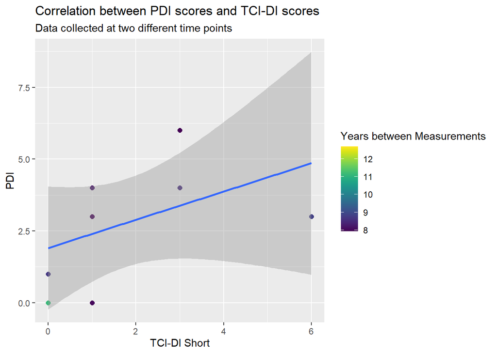

```r
ggplot(overlapdata_1c_3, aes(x=TCIPDI_short, y=PDI, colour=PET2PDI)) +
  geom_point(size=2) +
  geom_smooth(method="lm") +
  labs(x="TCI-DI Short",
       y="PDI",
       title="Correlation between PDI scores and TCI-DI scores",
       subtitle="Data collected at two different time points") +
  scale_colour_viridis("Years between Measurements")
```

```r
kable(describe(overlapdata_1c_3$PET2PDI))
```

|  | vars | n | mean | sd | median | trimmed | mad | min | max | range | skew | kurtosis | se |
| --- | --- | --- | --- | --- | --- | --- | --- | --- | --- | --- | --- | --- | --- |
| X1 | 1 | 9 | 9.107262 | 1.672288 | 8.526126 | 9.107262 | 0.7483256 | 7.929034 | 12.70502 | 4.775987 | 1.172678 | -0.2968349 | 0.5574293 |

## 1B, 2 and 4

```r
subjs_2 <- unique(as.character(D1S_summarygroup$SubjName))
subjs_1b <- unique(as.character(D1S_PDI_TCI$SubjName))

sum(subjs_2 %in% subjs_1b)
```

```
## [1] 20
```

```r
sum(subjs_1b %in% subjs_2)
```

```
## [1] 20
```

# Figure for confirmatory substudies 3 & 4

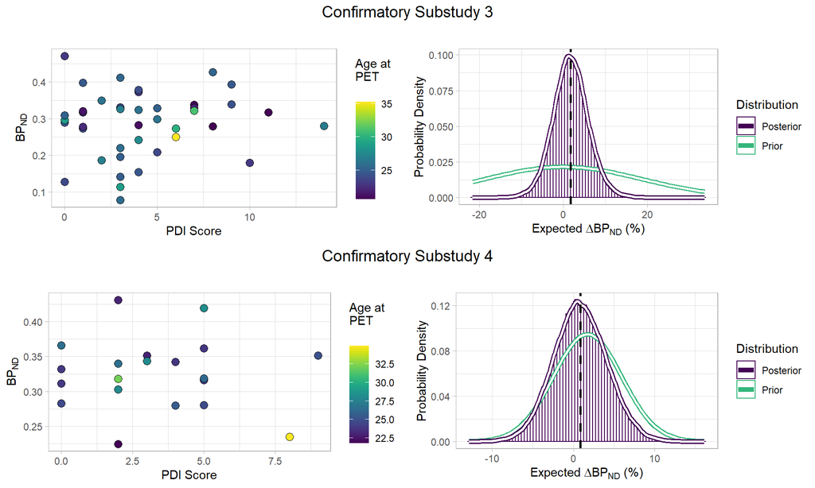

```r
ss3_scatter <- ss3_scatter + theme_light()
ss3_b3_parest <-ss3_b3_parest  + theme_light() +
  labs(x=expression(paste("Expected ", Delta, "", BP[ND],  " (%)"), sep=""))

ss4_scatter <- ss4_scatter + theme_light()
ss4_b3_parest <- ss4_b3_parest + theme_light() +
  labs(x=expression(paste("Expected ", Delta, "", BP[ND],  " (%)"), sep=""))

ss3_alignment <- cowplot::align_plots(ss3_scatter, ss3_b3_parest, align='v', axis='l')
ss3_row <- cowplot::plot_grid(ss3_alignment[[1]], ss3_alignment[[2]])


ss4_alignment <- cowplot::align_plots(ss4_scatter, ss4_b3_parest, align='v', axis='l')
ss4_row <- cowplot::plot_grid(ss4_alignment[[1]], ss4_alignment[[2]])

ss3_title <- cowplot::ggdraw() +
  cowplot::draw_label(
    "Confirmatory Substudy 3", hjust=0.5, vjust=0.5)

ss4_title <- cowplot::ggdraw() +
  cowplot::draw_label(
    "Confirmatory Substudy 4", hjust=0.5, vjust=0.5)

b3plots <- cowplot::plot_grid(ss3_title, ss3_row, ss4_title, ss4_row, ncol=1,
                              rel_heights = c(1,10,1,10))

b3plots
```

```r
ggsave(plot = b3plots, '../Figures/b3plots.jpg', width = 10, height=6, dpi=600)
```

# Post-Hoc Exploratory Analyses

## PDI Scales

Reviewers requested that we look at all the associations using the full PDI scale. Let’s first examine how correlated the full PDI scale is with the YesNo scale.

```r
Acrofix <- read_csv("../RawData_Clean/PETacronymKEY.csv")
DADB_PDI <- read_csv("../DerivedData/DADB_PDIsummary2.csv") %>%
  select(Acro = Acronym_Corrected, Main_A, Total) %>%
  left_join(Acrofix, by = c("Acro" = "PETAcro")) %>%
  select(SubjName = RandAcro, everything(), -Acro) %>%
  filter(!is.na(Main_A))
D1S_PDI <- read_csv("../DerivedData/D1S_persdata2.csv") %>%
  select(Acro = SubjName, Main_A, Total) %>%
  left_join(Acrofix, by = c("Acro" = "PETAcro")) %>%
  select(SubjName = RandAcro,  everything(), -Acro) %>%
  filter(!is.na(Main_A))
```

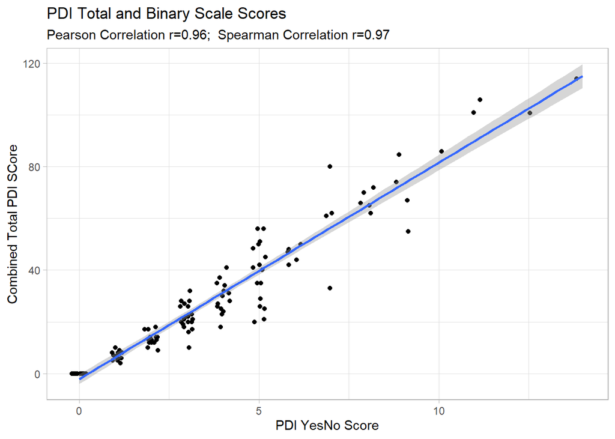

```r
PDI_all <- bind_rows(DADB_PDI, D1S_PDI)

PDI_cor_p <- round(cor(PDI_all$Main_A, PDI_all$Total), 2)
PDI_cor_s <- round(cor(PDI_all$Main_A, PDI_all$Total, method="spearman"), 2)

ggplot(PDI_all, aes(x=Main_A, y=Total)) +
  geom_jitter(height = 0, width = 0.2) +
  geom_smooth(method="lm") +
  theme_light() +
  labs(y="Combined Total PDI SCore",
       x="PDI YesNo Score",
       title="PDI Total and Binary Scale Scores",
       subtitle=glue::glue("Pearson Correlation r={PDI_cor_p};  ",
                           "Spearman Correlation r={PDI_cor_s}"))
```

These correlations are very high indeed. I don’t think this warrants running everything with the full PDI. I’ll run the overall monotonic association with it though.

Let’s just append the proper acronyms

## TCI-DI Information

Reviewers asked how related the TCI-DI was with the TCI scales, and with the items.

### Item-Level Correlations

In the large TCI dataset, first I correlated TCI-DI scores with each item individually.

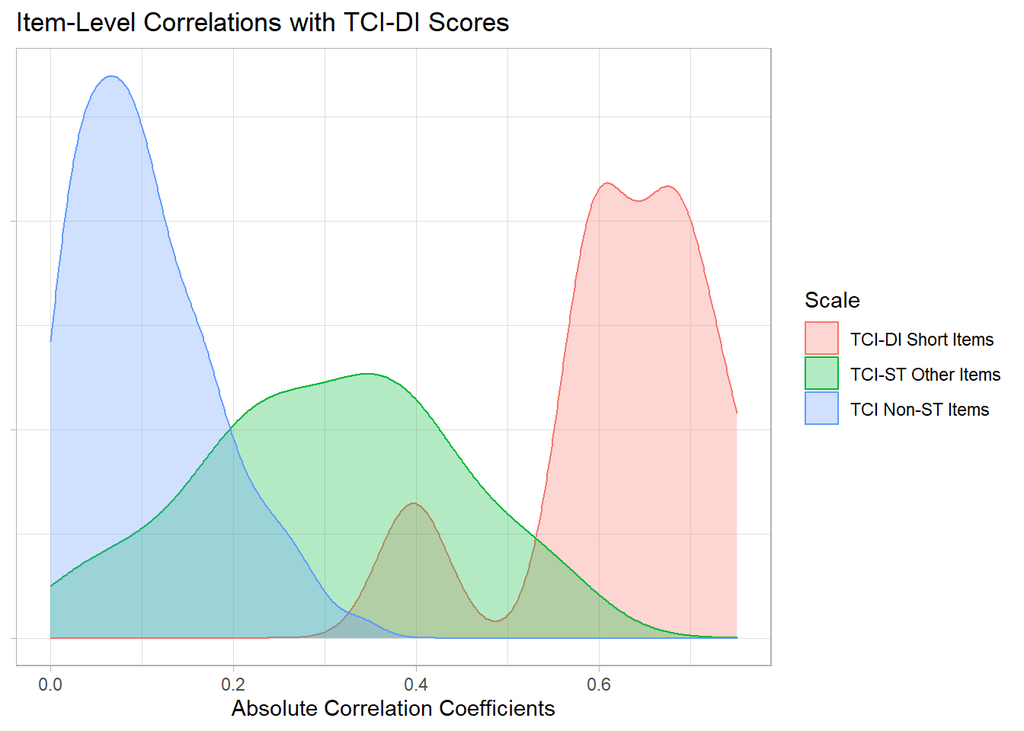

```r
TCI_cors <- read.csv('../DerivedData/TCIcors2.csv')

ggplot(TCI_cors, aes(x=abs(r), colour=Scale, fill=Scale)) +
  geom_density(alpha=0.3) +
  theme_light() +
  labs(x="Absolute Correlation Coefficients",
       y=NULL,
       title="Item-Level Correlations with TCI-DI Scores") +
  theme(axis.text.y = element_blank())
```

### Spiritual Transcendence Subscales

Next, I examined the correlations between the TCI-DI and the other ST scales, from which this scale is derived.

```r
TCIdf_summary <- read.csv(file = '../DerivedData/TCIdf_summary2.csv')

round(cor(TCIdf_summary[,-c(1,2)]), 2)
```

```
##        ST1  ST2  ST3   ST TCIDI
## ST1   1.00 0.46 0.52 0.82  0.58
## ST2   0.46 1.00 0.52 0.77  0.58
## ST3   0.52 0.52 1.00 0.86  0.91
## ST    0.82 0.77 0.86 1.00  0.86
## TCIDI 0.58 0.58 0.91 0.86  1.00
```

### PDI Associations

Lastly, in the dataset for which we have PDI and TCI scores, I examined the correlations between PDI scores and each of the TCI subscales.

```r
D1S_TCIPDI_PDI <- read.csv('../DerivedData/D1S_persdata2.csv')  %>%
  select(PDI_YesNo = Main_A, PDITotal = Total, TCIDI = TCIPDI_short,
         ST1, ST2, ST3, ST)

round(cor(D1S_TCIPDI_PDI), 2)
```

```
##           PDI_YesNo PDITotal TCIDI  ST1  ST2  ST3   ST
## PDI_YesNo      1.00     0.97  0.64 0.62 0.59 0.43 0.65
## PDITotal       0.97     1.00  0.66 0.59 0.59 0.47 0.66
## TCIDI          0.64     0.66  1.00 0.62 0.70 0.90 0.87
## ST1            0.62     0.59  0.62 1.00 0.62 0.48 0.86
## ST2            0.59     0.59  0.70 0.62 1.00 0.61 0.86
## ST3            0.43     0.47  0.90 0.48 0.61 1.00 0.81
## ST             0.65     0.66  0.87 0.86 0.86 0.81 1.00
```

## Monotonic relationships

Reviewers suggested we examine whether there was a monotonic nonlinear relationship between PDI scores and D1R BP<sub>ND</sub>, which we can test using a Spearman correlation test. First, we need to account for the effects of age on both PDI scores and D1R BP<sub>ND</sub>.

```r
# PDI
alldata_pdi <- alldata %>%
  filter(!is.na(PDI) & !is.na(bp)) %>%
  filter(Age < 50) %>%
  mutate( Age_PETc = Age - 25,
          Age_PDI = ifelse(is.na(Age_PDI), Age, Age_PDI),
          Age_PDIc = Age_PDI-25) %>%
  left_join(PDI_all) %>%
  rename(PDITotal = Total)
alldata_pdi_dlpfc <- alldata_pdi %>%
  filter(Region=="DLPFC_46")

alldata_pdi_str <- alldata_pdi %>%
  filter(Region=="gmfslSTR")


# TCI
alldata_tci <- alldata %>%
  filter(!is.na(TCIPDI_short) & !is.na(bp)) %>%
  filter(Age < 50) %>%
  mutate( Age_PETc = Age - 25)

alldata_tci_dlpfc <- alldata_tci %>%
  filter(Region=="DLPFC_46")

alldata_tci_str <- alldata_tci %>%
  filter(Region=="gmfslSTR")
```

Now we remove the effects of age.

Let’s define a function for this to avoid doing it multiple times.

```r
age_corr <- function(.data, bpcol, psychcol, bpagecol, psychagecol, studycol) {

  bpmodel    <- lm(.data[[bpcol]] ~ .data[[bpagecol]] + .data[[studycol]])
  psychmodel <- lm(.data[[psychcol]] ~ .data[[psychagecol]] + .data[[studycol]])

  Study_mult <- ifelse(paste0(".data[[studycol]]",
                              .data[[studycol]])==names(coef(bpmodel)[3]),
                       yes = 1, no=0)

  .data$bp_AgeCorr <- .data[[bpcol]] + (-1 * coef(bpmodel)[2] * .data[[bpagecol]]) +
    (-1 * Study_mult *  coef(bpmodel)[3])

  .data[[paste0(psychcol, "_AgeCorr")]] <- .data[[psychcol]] + (-1 *
                            coef(psychmodel)[2] * .data[[psychagecol]]) +
    (-1 * Study_mult *  coef(psychmodel)[3])

  return(.data)
}
```

### PDI YesNo

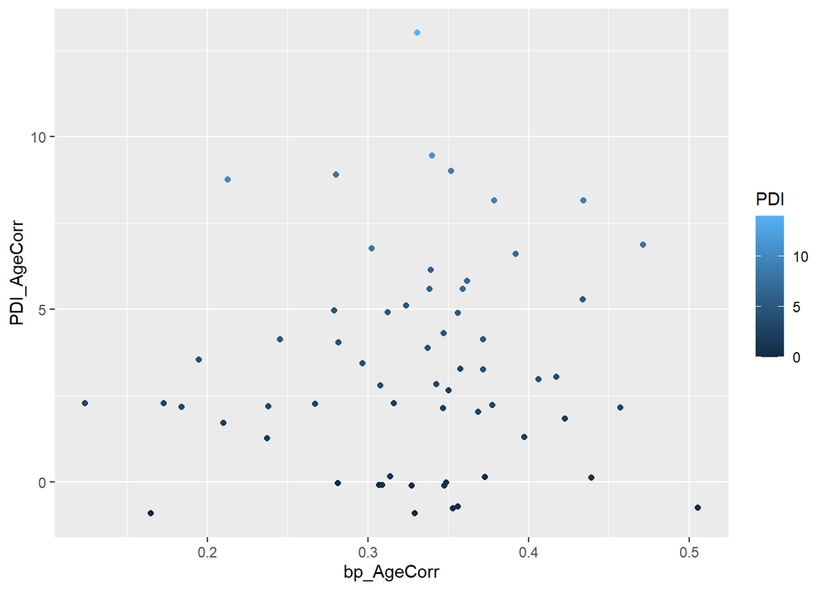

```r
alldata_pdi_dlpfc <- age_corr(alldata_pdi_dlpfc, "bp", "PDI",
                              "Age_PETc", "Age_PDIc", "Study")

ggplot(alldata_pdi_dlpfc, aes(x=bp_AgeCorr, y=PDI_AgeCorr)) +
  geom_point(aes(colour=PDI))
```

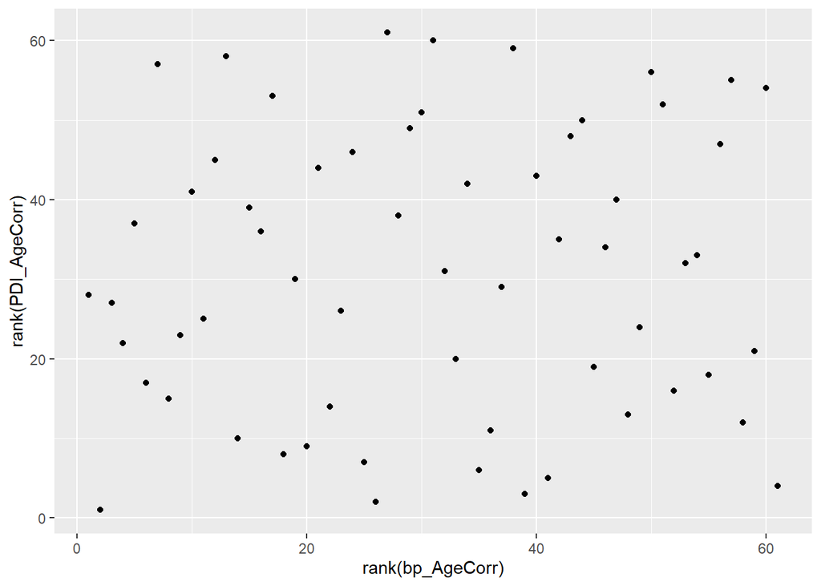

```r
ggplot(alldata_pdi_dlpfc, aes(x=rank(bp_AgeCorr), y=rank(PDI_AgeCorr))) +
  geom_point()
```

```r
cor(alldata_pdi_dlpfc$bp_AgeCorr, alldata_pdi_dlpfc$PDI_AgeCorr, method = "spearman")
```

```
## [1] 0.06150185
```

```r
cor(alldata_pdi_dlpfc$bp_AgeCorr, alldata_pdi_dlpfc$PDI_AgeCorr, method = "pearson")
```

```
## [1] 0.06535013
```

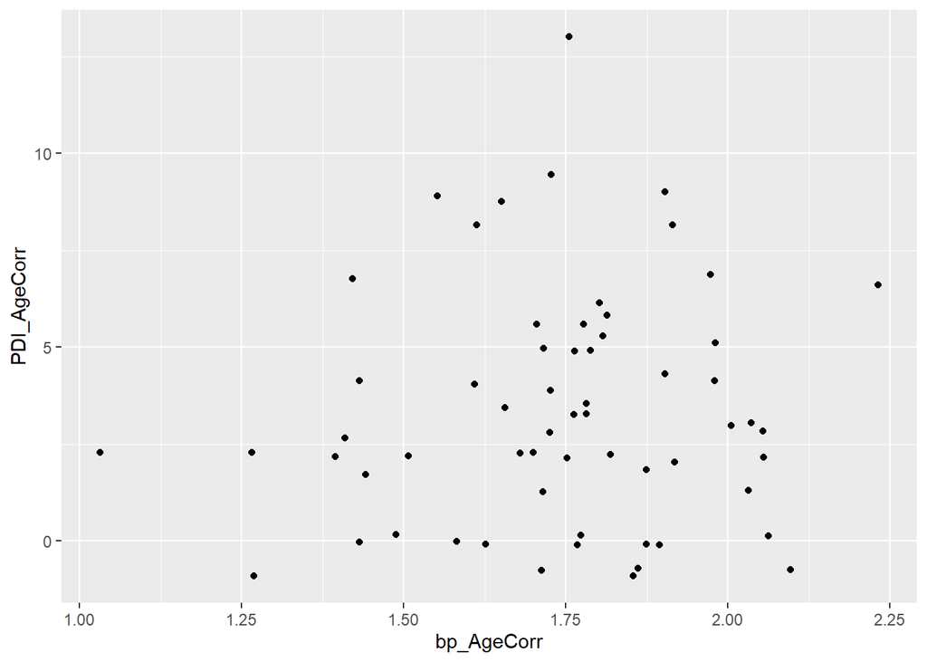

```r
alldata_pdi_str <- age_corr(alldata_pdi_str, "bp", "PDI",
                            "Age_PETc", "Age_PDIc", "Study")

ggplot(alldata_pdi_str, aes(x=bp_AgeCorr, y=PDI_AgeCorr)) +
  geom_point()
```

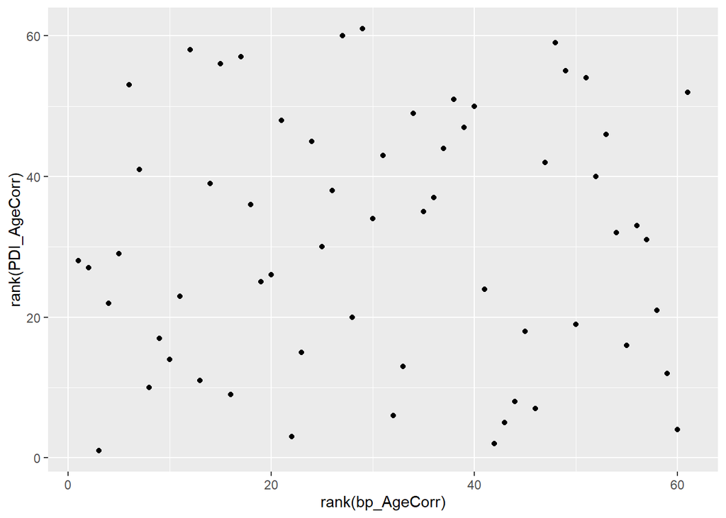

```r
ggplot(alldata_pdi_str, aes(x=rank(bp_AgeCorr), y=rank(PDI_AgeCorr))) +
  geom_point()
```

```r
cor(alldata_pdi_str$bp_AgeCorr, alldata_pdi_str$PDI_AgeCorr, method = "spearman")
```

```
## [1] 0.0392385
```

```r
cor(alldata_pdi_str$bp_AgeCorr, alldata_pdi_str$PDI_AgeCorr, method = "pearson")
```

```
## [1] 0.07583088
```

### TCI-DI

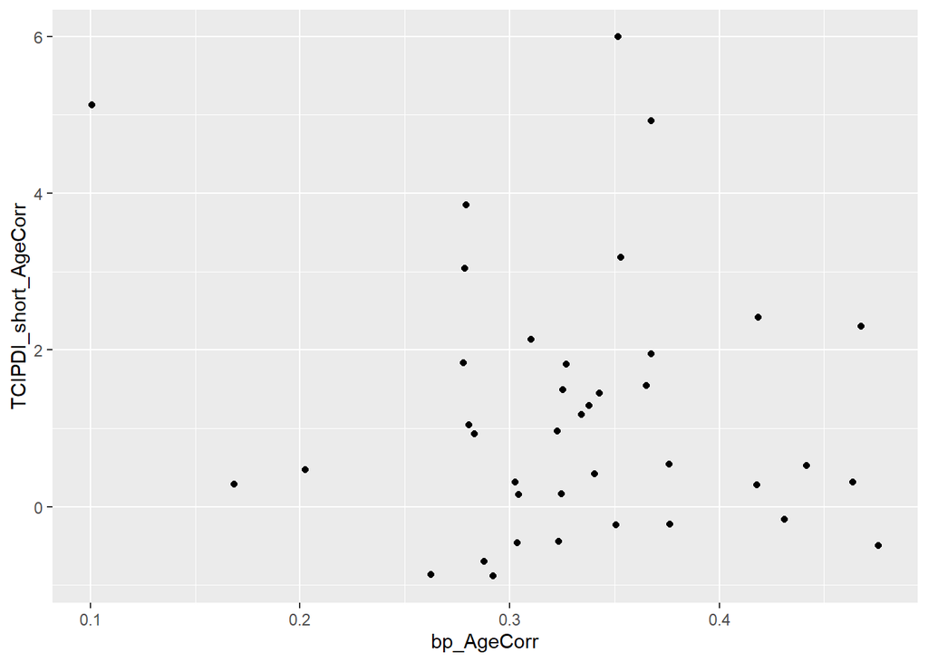

```r
alldata_tci_dlpfc <- age_corr(alldata_tci_dlpfc,  "bp", "TCIPDI_short",
                                    "Age_PETc", "Age_PETc", "Study")

ggplot(alldata_tci_dlpfc, aes(x=bp_AgeCorr, y=TCIPDI_short_AgeCorr)) +
  geom_point()
```

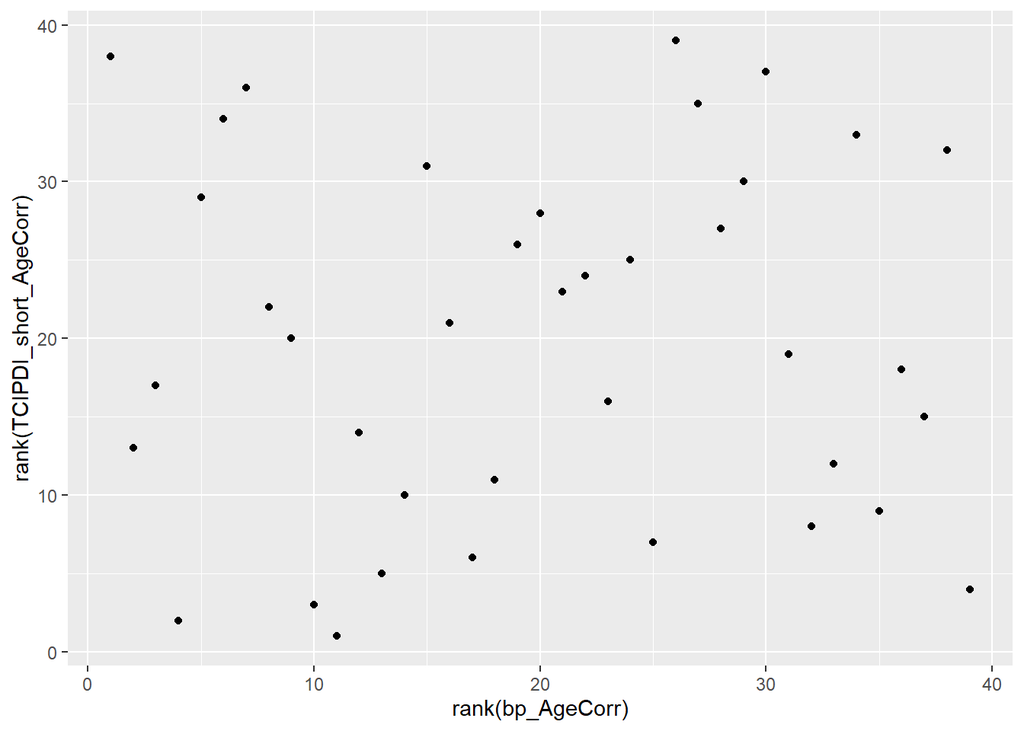

```r
ggplot(alldata_tci_dlpfc, aes(x=rank(bp_AgeCorr), y=rank(TCIPDI_short_AgeCorr))) +
  geom_point()
```

```r
cor(alldata_tci_dlpfc$bp_AgeCorr, alldata_tci_dlpfc$TCIPDI_short_AgeCorr, method = "spearman")
```

```
## [1] 0.0305668
```

```r
cor(alldata_tci_dlpfc$bp_AgeCorr, alldata_tci_dlpfc$TCIPDI_short_AgeCorr, method = "pearson")
```

```
## [1] -0.1466637
```

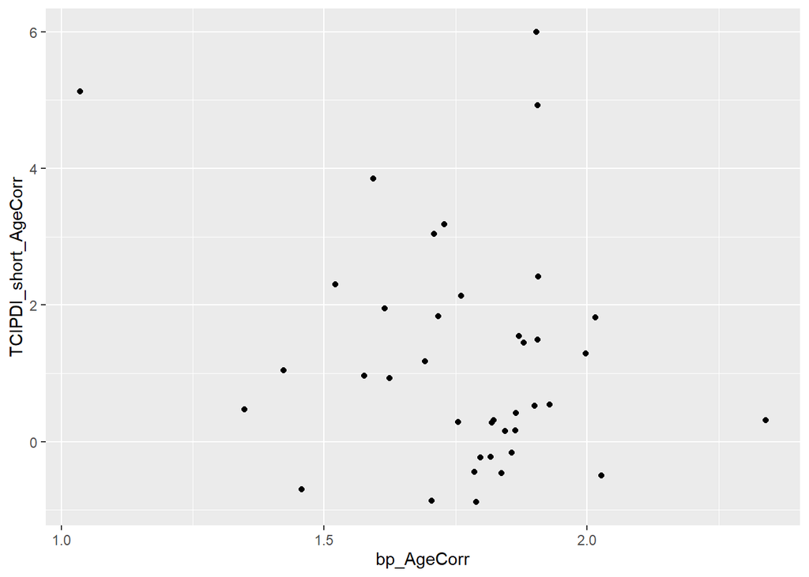

```r
alldata_tci_str <- age_corr(alldata_tci_str, "bp", "TCIPDI_short",
                            "Age_PETc", "Age_PETc", "Study")

ggplot(alldata_tci_str, aes(x=bp_AgeCorr, y=TCIPDI_short_AgeCorr)) +
   geom_point()
```

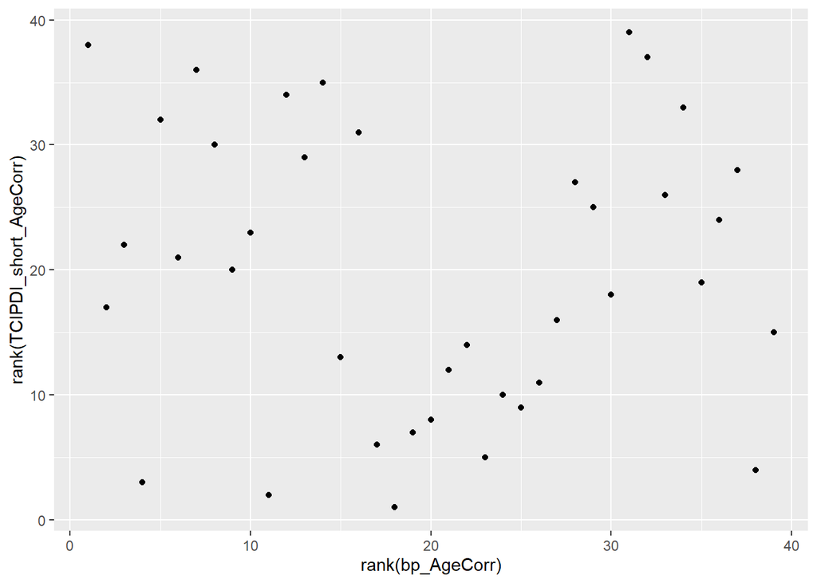

```r
ggplot(alldata_tci_str, aes(x=rank(bp_AgeCorr), y=rank(TCIPDI_short_AgeCorr))) +
   geom_point()
```

```r
cor(alldata_tci_str$bp_AgeCorr, alldata_tci_str$TCIPDI_short_AgeCorr, method = "pearson")
```

```
## [1] -0.2218147
```

```r
cor(alldata_tci_str$bp_AgeCorr, alldata_tci_str$TCIPDI_short_AgeCorr, method = "spearman")
```

```
## [1] -0.06214575
```

### PDI Total

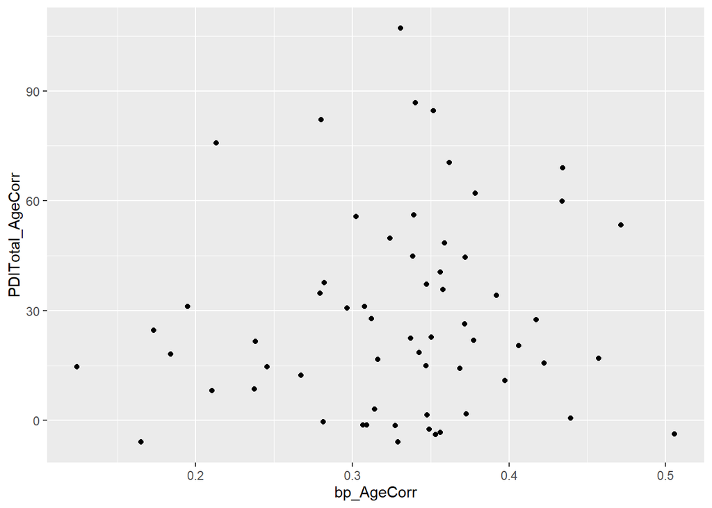

```r
alldata_pditot_dlpfc <- age_corr(alldata_pdi_dlpfc, "bp", "PDITotal",
                              "Age_PETc", "Age_PDIc", "Study")

ggplot(alldata_pditot_dlpfc, aes(x=bp_AgeCorr, y=PDITotal_AgeCorr)) +
  geom_point()
```

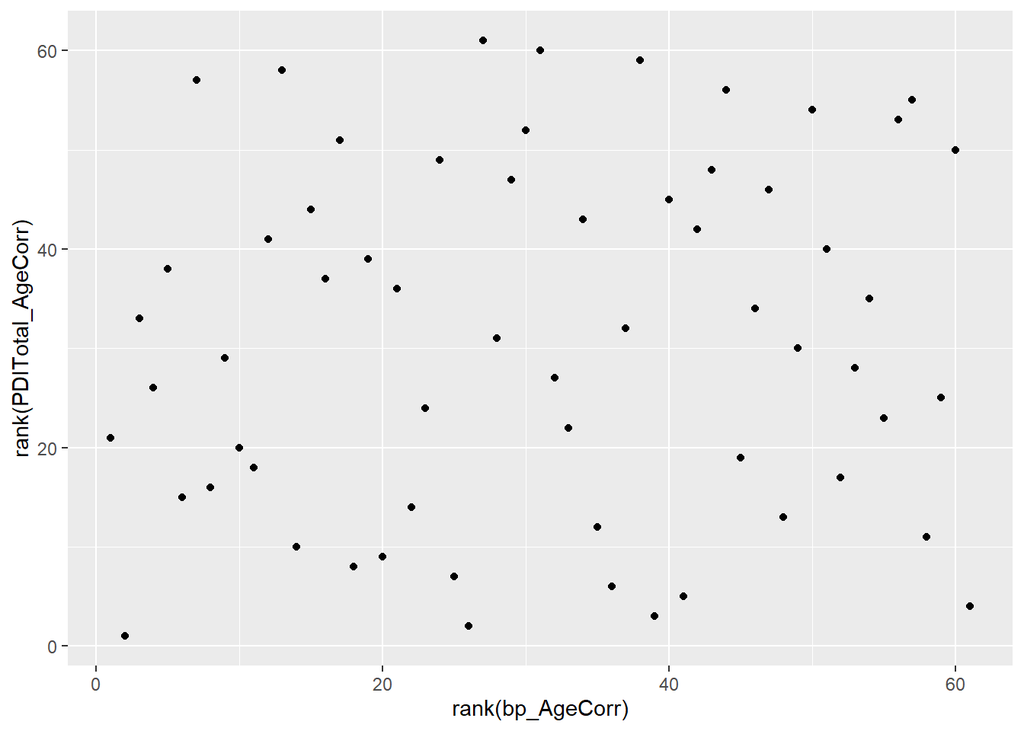

```r
ggplot(alldata_pditot_dlpfc, aes(x=rank(bp_AgeCorr), y=rank(PDITotal_AgeCorr))) +
  geom_point()
```

```r
cor(alldata_pditot_dlpfc$bp_AgeCorr, alldata_pditot_dlpfc$PDITotal_AgeCorr, method = "spearman")
```

```
## [1] 0.09962983
```

```r
cor(alldata_pditot_dlpfc$bp_AgeCorr, alldata_pditot_dlpfc$PDITotal_AgeCorr, method = "pearson")
```

```
## [1] 0.08797421
```

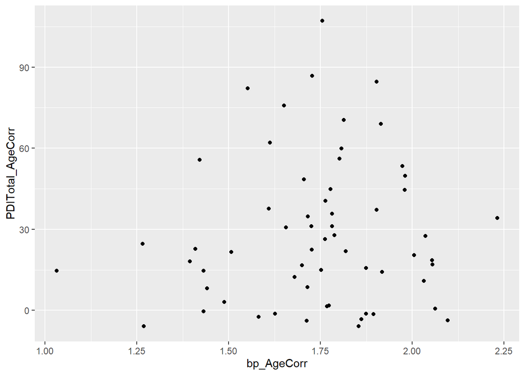

```r
alldata_pditot_str <- age_corr(alldata_pdi_str, "bp", "PDITotal",
                            "Age_PETc", "Age_PDIc", "Study")

ggplot(alldata_pditot_str, aes(x=bp_AgeCorr, y=PDITotal_AgeCorr)) +
  geom_point()
```

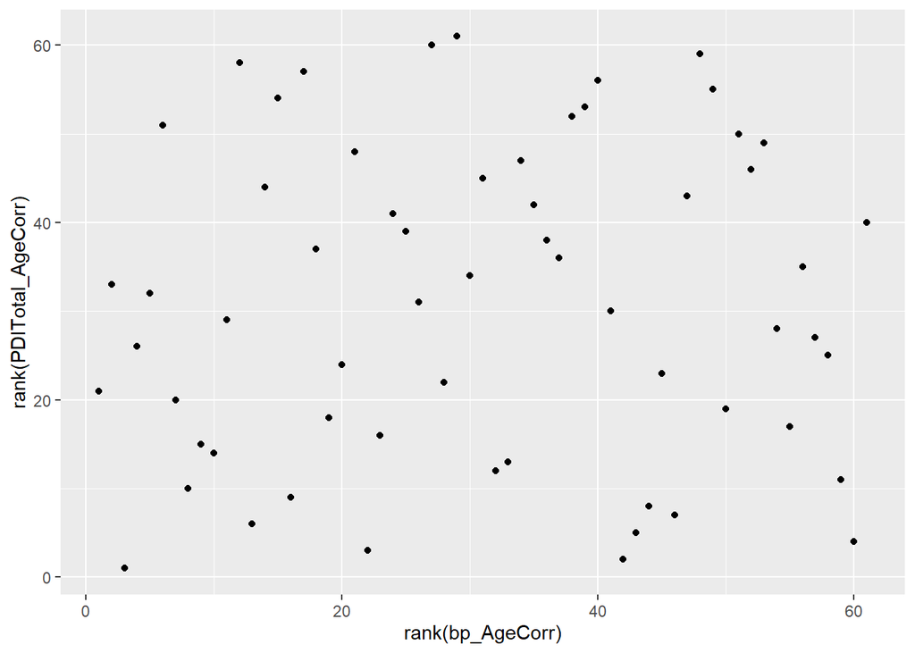

```r
ggplot(alldata_pditot_str, aes(x=rank(bp_AgeCorr), y=rank(PDITotal_AgeCorr))) +
  geom_point()
```

```r
cor(alldata_pditot_str$bp_AgeCorr, alldata_pditot_str$PDITotal_AgeCorr, method = "spearman")
```

```
## [1] 0.06054997
```

```r
cor(alldata_pditot_str$bp_AgeCorr, alldata_pditot_str$PDITotal_AgeCorr, method = "pearson")
```

```
## [1] 0.07713654
```